# Disaster Relief Project Part2

Jay Hombal

02/19/2020

# 1 Define Problem:

This project is a classification data-mining problem for locating displaced persons living in makeshift shelters following the destruction of the earthquake in Haiti in 2010.

Following that earthquake, rescue workers, mostly from the United States military, needed to get food and water to the displaced persons. But with destroyed communications, impassable roads, and thousands of square miles, actually locating the people who needed help was challenging.

As part of the rescue effort, a team from the Rochester Institute of Technology flew an aircraft to collect high-resolution geo-referenced imagery. It was known that the people whose homes had been destroyed by the earthquake were creating temporary shelters using blue tarps, and these blue tarps would be good indicators of where the displaced persons were - if only they could be located in time, out of the thousands of images that would be collected every day. The problem was that there was no way for aid workers to search the thousands of images in time to find the blue tarps and communicate the locations back to the rescue workers on the ground in time. The solution would be provided by data-mining algorithms, which could search the images faster and more thoroughly (and accurately?) then humanly possible.

**The goal was to find an algorithm that could effectively search the images to locate displaced persons and communicate those locations rescue workers so they could help those who needed it in time.**

# 2 Prepare Problem

## 2.1 Load libraries

```r
# load all required libraries
library(plyr)
library(tidyverse)
library(yardstick)
library(gridExtra)
library(caret)
library(MASS)
library(pROC)
library(doParallel)
library(tune)
library(stringr)
library(rlist)
library(ISLR)
library(recipes)
```

## 2.2 References

```r
# following external resources were referred

# Books: (in addition to the textbook)
# ap-modeling : Applied Predictive Modeling by Max Kuhn, Kjell Johnson
# ml-JasonB:     Machine learning Mastery with R-Get Started by Jason BrownLee

# external references labeled with ref : <label> tag in line with code,
# links mapped to label in this section

# pr-auc:     https://blog.zenggyu.com/en/post/2019-03-03/how-to-plot-roc-and-precision-recall-curves/
# multi-core: https://blog.zenggyu.com/en/post/2019-03-03/how-to-plot-roc-and-precision-recall-curves/
# boxplot:    https://stackoverflow.com/questions/1249548/side-by-side-plots-with-ggplot2
# transform:  https://r4ds.had.co.nz/transform.html
# test-harness: https://topepo.github.io/caret/model-training-and-tuning.html#control
# tuning :    https://www.machinelearningplus.com/machine-learning/caret-package/#6trainingandtuningthemodel
# tune-grid:  https://machinelearningmastery.com/tune-machine-learning-algorithms-in-r/
# plot-cfm2: https://stackoverflow.com/questions/37897252/plot-confusion-matrix-in-r-using-ggplot
# theme-setting: https://bookdown.org/yihui/rmarkdown/slidy-presentation.html#text-size
# glmnet-se : https://stats.stackexchange.com/questions/299653/caret-glmnet-vs-cv-glmnet
# penalized-lr : http://www.sthda.com/english/articles/36-classification-methods-essentials/149-penalized-logistic-regression-essentials-in-r-ridge-lasso-and-elastic-net/
# reg-lr: https://bradleyboehmke.github.io/HOML/regularized-regression.html
# un-register: https://csantill.github.io/RTuningModelParameters/
# mote-svm: https://rpubs.com/uky994/593668
# ref-paper1: https://www.jstor.org/stable/2242400?seq=1
# tws-dsl1l2: https://towardsdatascience.com/l1-and-l2-regularization-methods-ce25e7fc831c
# rda : https://daviddalpiaz.github.io/r4sl/regularized-discriminant-analysis.html
```

## 2.3 Enable parallel processing

```r
# code shared by Derek - to improve speed
# ref: multi-core
cores <- parallel::detectCores()
cl <- makePSOCKcluster(cores)
registerDoParallel(cl)
grid_control <-
  control_grid(verbose = TRUE,pkgs = "doParallel",allow_par = TRUE)
```

## 2.4 Functions

Following are the helper/utility functions mainly abstract repetitive code. These functions are called late in data exploring and model evaluations.

### 2.4.1 Determine best threshold

```r
#' Prints precision-recall curve AUC and returns best threshold for pr curve
#' @param classifier - classifier
#'
#' @examples = get_best_threshold_from_pr_curve(classifier = lr_fit)
#' ref: pr-auc
get_best_threshold_from_pr_curve <- function(classifier) {


  # precision-recall-auc
  prauc <- classifier$pred %>% pr_auc(obs, BlueTarp)

  #pr_input_df <- as.data.frame(lr_fit$pred)
  #dplyr::select(pr_input_df, obs, BlueTarp)

  # precision-recall curve
  prcurve <- classifier$pred %>%
  pr_curve(obs,BlueTarp, event_level = 'first')

  # threshold, recall and precision
  mythreshold <- prcurve[['.threshold']]
  myrecall <- prcurve[['recall']]
  myprecision <- prcurve[['precision']]

  # ref: ml-JasonB
  #f1_score <-
  #  (2  * myrecall * myprecision) / (myrecall + myprecision)
  #f2_score <-
  #  ((1 + 2^2) * myrecall * myprecision) / (2^2 * (myrecall + myprecision))
  f0.5_score <-
    ((1 + 0.5^2) * myrecall * myprecision) / (0.5^2 * (myrecall + myprecision))

  # index of max f_Score
  ix <- which.max(f0.5_score)
  #ix <- which.max(f1_score)

  # best threshold from pr_curve
  best_threshold <- mythreshold[ix]
  print(paste(classifier$method, 'best threshold:', round(best_threshold,4)))
  return(best_threshold)

}
```

### 2.4.2 Confusion matrix utility functions

#### 2.4.2.1 Get confusion matrix

```r
#' Returns confusion matrix
#' @param classifier - classifier
#'
#' @examples = get_confusion_matrix(classifier = lr_fit, 0.4)
#' ref: plot_cfm2
get_confusion_matrix <- function(classifier , thres = 0.5) {

  classifier$pred <-
    mutate(classifier$pred, pred_class = if_else(BlueTarp >= thres,
                                               "BlueTarp", "NotBlueTarp"))

  classifier$pred$pred_class <- factor(classifier$pred$pred_class,
                                       levels = c('BlueTarp', 'NotBlueTarp'))
  cfm <- confusionMatrix(data = classifier$pred$pred_class,
                         reference = classifier$pred$obs,
                         mode = 'everything',
                         positive = 'BlueTarp')
  return (cfm)
}
```

#### 2.4.2.2 Plot confusion matrix

```r
#' Returns ggplot confusion matrix
#' @param classifier - classifier
#'
#' @examples = plot_confusion_matrix(classifier = lr_fit, 0.4)
# ref: plot_cfm2
plot_confusion_matrix <- function(classifier , thres = 0.5) {

  cfm <- get_confusion_matrix(classifier, thres)
  table <- data.frame(cfm$table)

  # reference provided @ref: plot_cfm2, I likes the code with label 'good'
  # and 'bad' predictions so kept the code as is.
  plotTable <- table %>%
    mutate(goodbad =
      ifelse(table$Prediction == table$Reference, "good", "bad")) %>%
      group_by(Reference) %>%
      mutate(prop = Freq/sum(Freq))

  cfm_plot <- ggplot(data = plotTable,
                mapping = aes(x = Reference, y = Prediction,
                              fill = goodbad, alpha = Freq)) +
              geom_tile() +
              geom_text(aes(label = Freq),
                        vjust = .5, fontface  = "bold", alpha = 1) +
              scale_fill_manual(values = c(good = "green", bad = "red")) +
              labs(title = paste("Confusion Matrix for",
                                 toupper(classifier$method)),
                   subtitle = paste("Threshold:", round(thres,4))) +
              theme_bw() +
              xlim(rev(levels(table$Reference)))


    return (cfm_plot)

}
```

#### 2.4.2.3 Get holdout confusion matrix

```r
#' Returns confusion matrix
#' @param reference - holdout_data Class variable as the reference
#' @param holdout_data_prob - probabilities from the predict function
#'                            for positive class
#' @param threshold - threshold (default = 0.5)
#'
#' @examples = get_confusion_matrix(classifier = lr_fit, 0.4)
#' ref: plot_cfm2
get_holdout_confusion_matrix <-
  function(reference, holdout_data_prob, thres = 0.5) {


  holdout_data_pred <- as.factor(
  ifelse(holdout_data_prob$BlueTarp >=thres,'BlueTarp','NotBlueTarp'))

  cfm <- confusionMatrix(data = holdout_data_pred, reference = reference,
                         mode='everything', positive = 'BlueTarp')

  return (cfm)
}
```

#### 2.4.2.4 Plot holdout confusion matrix

```r
#' Returns ggplot confusion matrix for holdout dataset
#' @param reference - holdout_data Class variable as the reference
#' @param holdout_data_prob - probabilities from the predict function
#'                            for positive class
#' @param threshold - threshold (default = 0.5)
#' @param method - classifier method name
#'
#' @examples = plot_confusion_matrix(classifier = lr_fit, 0.4)
#' ref: plot_cfm2
# ref: plot_cfm2
plot_holdout_confusion_matrix <-
  function(reference, holdout_data_prob, thres = 0.5 , method) {

  holdout_data_pred <- as.factor(
  ifelse(holdout_data_prob$BlueTarp >=thres,'BlueTarp','NotBlueTarp'))

  cfm <- confusionMatrix(reference = reference,
                                   data = holdout_data_pred,
                                   mode='everything',
                                   positive = 'BlueTarp')

  table <- data.frame(cfm$table)

  # reference provided @ref: plot_cfm2, I likes the code with label 'good'
  # and 'bad' predictions so kept the code as is.
  plotTable <- table %>%
    mutate(goodbad =
      ifelse(table$Prediction == table$Reference, "good", "bad")) %>%
      group_by(Reference) %>%
      mutate(prop = Freq/sum(Freq))

  cfm_plot <- ggplot(data = plotTable,
                mapping = aes(x = Reference, y = Prediction,
                              fill = goodbad, alpha = Freq)) +
              geom_tile() +
              geom_text(aes(label = Freq),
                        vjust = .5, fontface  = "bold", alpha = 1) +
              scale_fill_manual(values = c(good = "green", bad = "red")) +
              labs(title = paste("Confusion Matrix for",toupper(method)),
                   subtitle = paste("Threshold:", round(thres,4))) +
              theme_bw() +
              xlim(rev(levels(table$Reference)))

    return (cfm_plot)

}
```

#### 2.4.2.5 Out_of_sample confusion matrix

```r
#' Returns out of sample k-fold confusion matrix
#'
#' @param classifer - classifier
#'
#' @examples get_CM(knn_fit)
get_CM <- function (classifier, threshold = 0.5) {

  CM <- classifier$pred %>%
    dplyr::mutate(pred2 =
                  ifelse(BlueTarp > threshold, "BlueTarp", "NotBlueTarp")) %>%
    dplyr::mutate(pred2 =
                    factor(pred2, levels = c("BlueTarp", "NotBlueTarp"))) %>%
    dplyr::group_split(Resample) %>%
    purrr::map(~ caret::confusionMatrix(data = .x$pred2, reference=.x$obs,
                                        positive='BlueTarp'))
  return (CM)
}
```

### 2.4.3 PR_curve & other helper functions

#### 2.4.3.1 False discovery rate

```r
#' Calculate FDR
#'
#' @param cfmtable - confusion matrix
#'
#' @return FDR value
#'
#' @examples fdr(caret::confusionmatrix$table)
fdr <- function(cfmtable) {
  TN <- cfmtable[1,1]
  TP <- cfmtable[2,2]
  FP <- cfmtable[1,2]
  FN <- cfmtable[2,1]
  return ( FP / (FP+TP))
}
```

#### 2.4.3.2 Plot pr curve

```r
#' Plot Precision Recall Curve & Print AUC
#' @param classifier - classifier
#'
#' @examples = plot_pr_curve(classifier = lr_fit)
#' ref: pr-auc
plot_pr_curve <- function(classifier) {
  # print AUC
  pr_auc <- classifier$pred %>% pr_auc(obs, BlueTarp,
                                       event_level='first')

  # plot PR curve
  pr_dat <- classifier$pred %>% pr_curve(obs, BlueTarp,
                                         event_level='first')
  prcurve <- pr_dat %>%
    arrange(.threshold) %>%
    ggplot() +
    labs(title = paste(toupper(classifier$method),"PR curve"),
         subtitle = paste("PR AUC:", round(pr_auc[['.estimate']],4))) +
    geom_path(mapping = aes(recall, precision)) +
    theme (plot.background = element_rect(size = 0.5, color = 'azure4'),
           axis.line = element_line(size = 0.5 , color="grey37"),
           title = element_text(color = 'dodgerblue4'),
           line = element_line(size = 0.5 , color="blue"))

  # return PR curve object
  return (prcurve)
}
```

#### 2.4.3.3 Holdout plot pr curve

```r
#' Plot Precision Recall Curve & Print AUC for holdout data
#' @param classifier - classifier
#' @param method - method name
#'
#' @examples = plot_pr_curve(prob = knn_holdout_prob, 'knn')
#' ref: pr-auc
holdout_data_plot_pr_curve <- function(prob, method) {
  p1 <- knn_holdout_prob
  pr_auc <-  pr_auc(prob, holdout_data$Class, BlueTarp, event_level = 'first')

  # plot PR curve
  pr_dat <- pr_curve(prob, holdout_data$Class, BlueTarp, event_level = 'first')

  prcurve <- pr_dat %>%
    arrange(.threshold) %>%
    ggplot() +
    labs(title = paste(toupper(method),"PR curve"),
      subtitle = paste("PR AUC:", round(pr_auc[['.estimate']],4))) +
    geom_path(mapping = aes(recall, precision)) +
    theme (plot.background = element_rect(size = 0.5, color = 'azure4'),
           axis.line = element_line(size = 0.5 , color="grey37"),
           title = element_text(color = 'dodgerblue4'),
           line = element_line(size = 0.5 , color="blue"))

  return(prcurve)

}
```

#### 2.4.3.4 Class summary

```r
#' Summarize the class distribution
#'
#' @param haiti_ds - accepts train_data or holdout_data
#'
#' @examples class_summary_by_percentage(holdout_data)

class_summary_by_precentage <- function(haiti_ds) {
  percentage <- prop.table(table(haiti_ds$Class)) * 100
  print(cbind(frequency = table(haiti_ds$Class), percentage))

  ggplot(data=haiti_ds) +
  geom_bar(mapping=aes(x=Class, fill=Class))

}
```

#### 2.4.3.5 Box plots

```r
#' Plot box plots for by class for variables Red, Green and Blue
#'
#' @param haiti_ds - accepts train_data or holdout_ata
#'
#' @examples plot_boxplots_byclass(holdout_data)
plot_boxplots_byclass <- function(haiti_ds) {
# ref: boxplot
  require(gridExtra)
  holdout_boxplot1 <- ggplot2::ggplot(data=haiti_ds) +
    geom_boxplot(mapping = aes(x=Class, y=Red, fill=Class))+
    theme(legend.position = "top" , legend.direction="vertical")


  holdout_boxplot2 <- ggplot2::ggplot(data=haiti_ds) +
    geom_boxplot(mapping = aes(x=Class, y=Green, fill=Class))+
    theme(legend.position = "top", legend.direction="vertical")


  holdout_boxplot3 <- ggplot2::ggplot(data=haiti_ds) +
    geom_boxplot(mapping = aes(x=Class, y=Blue, fill=Class))+
    theme(legend.position = "top" ,legend.direction="vertical")

  grid.arrange(holdout_boxplot1, holdout_boxplot2, holdout_boxplot3, ncol=3)

}
```

#### 2.4.3.6 Get metric

```r
#' Return a metric value from caret confusion matrix object
#'
#' @param caret_CM - caret confusion matrix
#' @param metric_name -  confusion matrix metric_name
#'
#' @examples get_metric(caret_CM_knn, 'sensitivity')
get_metric <- function(caret_CM, metric_name) {
  caret_CM %>% broom::tidy() %>%
    dplyr::filter(term == metric_name) %>%
    dplyr::select(estimate) %>% pull()
}
```

#### 2.4.3.7 Get metric func

```r
#' Return a metric value from caret confusion matrix object for all folds
#'
#' @param caret_CM_objects - caret confusion matrix for k folds
#' @param metric_name -  confusion matrix metric_name
#' @param func -  stat function (mean ,median, sd etc)
#'
#' @examples get_metric_func(caret_CM_knn, 'sensitivity', mean)
#' @examples get_metric_func(caret_CM_knn, 'sensitivity', sd)
get_metric_func <- function(caret_CM_objects, metric_name, func) {
  caret_CM_objects %>%
    purrr::map(~ get_metric(.x, metric_name)) %>%
    unlist() %>% func
}
```

#### 2.4.3.8 Get uncertainty measures

```r
#' Returns a data frame of mean sensitivity and std. dev. of sensititivity and
#' fold level sensitivity
#'
#' @param classifiers - list of classifiers
#'
#' @examples get_uncertainty(classifiers)

get_uncertainty_measures <- function (classifiers) {

  uncertainity_ds = data.frame(Characters=character(),dbl= double(),
                               dbl=double(),dbl=double(),dbl=double(),
                               dbl=double(),dbl=double(),dbl=double(),
                               dbl=double(),dbl=double(),dbl=double(),
                               dbl=double(),dbl=double())
  column_names = c('method','mean-sensitivity' , 'sdev', 'fold1',
                   'fold2','fold3','fold4','fold5','fold6','fold7','fold8',
                   'fold9','fold10')
  names(uncertainity_ds) <- column_names

  for (classifer in classifiers) {
    method_name = classifer$method
    #print(paste("method: " , method_name))
    # get out-of-fold confusion matrix
    out_of_foldsCM = get_CM(classifer)
    fold_senitivities = vector("integer", 10)
    i = 1
    for (cm in out_of_foldsCM) {
      fold_senitivities[i] <- get_metric(cm, 'sensitivity')
      i = i + 1
    }
    #print(fold_senitivities)
    mean_sensitivity <- get_metric_func(out_of_foldsCM, 'sensitivity', mean)
    #print(paste("mean_sensitivity: " , mean_sensitivity))

    sdev <- get_metric_func(out_of_foldsCM, 'sensitivity', sd)
    #print(paste("sdev: " , sdev))

    uncertainity_ds <- uncertainity_ds %>% add_row('method' = method_name,
                                'mean-sensitivity' = mean_sensitivity,
                                'sdev' = sdev, 'fold1' = fold_senitivities[1],
                                'fold2' = fold_senitivities[2],
                                'fold3' = fold_senitivities[3],
                                'fold4' = fold_senitivities[4],
                                'fold5' = fold_senitivities[5],
                                'fold6' = fold_senitivities[6],
                                'fold7' = fold_senitivities[7],
                                'fold8' = fold_senitivities[8],
                                'fold9' = fold_senitivities[9],
                                'fold10' = fold_senitivities[10])
  }
  return (uncertainity_ds)
}
```

#### 2.4.3.9 Clean global env

```r
#' ref: unregister
#' Clean or remove objects from env
#'
#'
#' @examples unregister()
unregister <- function() {
  env <- foreach:::.foreachGlobals
  rm(list=ls(name=env), pos=env)
}
```

### 2.4.4 parameter tuning & model fit functions

#### 2.4.4.1 Get tune grid

```r
#' ref: tune-grid
#' Returns model specific tune grid
#'
#' @param method - learning method name
#'                 (must be valid caret train function options)
#'
#' @examples get_tune_grid(method = 'glm')

get_tune_grid <- function (method) {


    # knn
    if (method == 'knn') {
      knn_tune_grid <- expand.grid(.k=seq(1,10,by=2))
      return (knn_tune_grid)
    }
    # svc
    else if (method == 'svm') {
      svm_tune_grid <-
        expand.grid(sigma=c(0.025, 0.05, 0.1), C=seq(1, 5, by=1))
      return (svc_tune_grid)
    }
    # rf
    else if (method == 'rf') {
      #mtry = sqrt(ncol(train_data[,2:4]))
      #rf_tune_grid = expand.grid(.mtry = mtry)
      rf_tune_grid = expand.grid(.mtry = c(1:5))
      return (rf_tune_grid)
    }
    # lda using penalized discriminant analysis
    # ref-paper1
    else if (method == 'pda') {
      lda_tune_grid = expand.grid(lambda = seq(0.001,1, length=5))
      return (lda_tune_grid)
    }
    # rda using regularized discriminant analysis
    # ref-paper1
    else if (method == 'rda') {
      #gamma  and lambda are as mixing parameters, as they both take values between 0 and 1
      lda_tune_grid = expand.grid(gamma = seq(0.01, 1, length= 5), lambda = seq(0.001,1, length=5))
      return (lda_tune_grid)
    }
    # lr
    else if (method == 'lr') {
      # ref : reg-lr
      # To regularize lr model we can use the glmnet::glmnet() function.
      # The alpha parameter in glmnet is used to perform a ridge (alpha = 0),
      # lasso (alpha = 1), or elastic net (0 < alpha < 1) model
      lr_tune_grid = expand.grid(alpha = 0:1,lambda = seq(0.001,1, length=5))
      return (lr_tune_grid)
    }
    # NULL
    else {
      return (NULL)
    }
}
```

**Tuning Models Explained**

$${\rm RSS} + \lambda \sum_{j=1}^p |\beta_j|$$

$${\rm RSS} + \lambda \sum_{j=1}^p \beta_j^2$$

When $\lambda = 0$, for both, its just simple logistic regression. The key difference is that the *Lasso* pushes the coefficients of insignificant variables to zero, works better when the dataset has more features. *Ridge* regularization does shrink the coefficents towards zero but now zero

#### 2.4.4.2 Fit model

```r
#' ref: tune-grid
#' Returns fitted model
#'
#' @param method - learning method name
#'                 (must be valid caret train function options)
#'
#' @examples fit_model(train_data, method = 'glmnet')
fit_model <- function (data = data, method="knn",
                       metric = "Accuracy" , baseline=FALSE) {
  # model formula
  model_formula = formula(Class ~ Blue + Green + Red)
  tr_control = ifelse(baseline == TRUE, 'method = \'none\'', fitControl)
  start_time <- proc.time()

  if (baseline == FALSE) {
    set.seed(seed)
    model_fit <- caret::train(model_formula, data=data,
                  method=method, preProcess=c("center","scale"),
                  metric = metric,
                  # if method none simply fit on entire the dataset
                  trControl= fitControl,
                  tuneGrid = get_tune_grid(method))
  } else {
    set.seed(seed)
    model_fit <- caret::train(model_formula, data=data,
                  method=method, preProcess=c("center","scale"),
                  metric = metric,
                  # if method none simply fit on entire the dataset
                  trControl= fitControl,
                  tuneGrid = NULL,
                  tuneLength = 1)

  }

  return (model_fit)
}
```

# 3 Prepare & Analyze Data

Next, we will load both training and holdout data set.

## 3.1 Initialize data files & folders

```r
setwd("C:/Users/mhomb/Documents/UVA-MSDS/Courses/SYS6018/code/sys6018/disaster_relief_project_part2")
train_data_file  <- "./data/HaitiPixels.csv"
hold_out_data_folder <- "./data/hold-out-data"
holdout_data_files =
  list.files(path = hold_out_data_folder, pattern = "*.txt", full.names = TRUE)
```

## 3.2 Load train data

```r
seed = 199
# load the CSV file from the local directory (in part one this was used as the full dataset)
train_data <-
  read.csv(train_data_file, header = TRUE, sep = ",", stringsAsFactors = TRUE)
```

## 3.3 Load & transform holdout data

```r
# creating an empty dataset
holdout_data = data.frame(Ints=integer(),Ints=integer(),Ints=integer(),
                        Characters=character(),stringsAsFactors=FALSE)
mycolnames = c('Class','Red','Green','Blue')
names(holdout_data) <- mycolnames

for (file in holdout_data_files) {
  ho_ds_temp  <-
    read.table(file, skip = 8,header = F,sep = "",na.strings = "", as.is = TRUE,
    col.names = c('ID','X','Y','MapX','MapY','Lat','Lon','Red','Green','Blue'))
    ho_ds_temp <- dplyr::select(ho_ds_temp, Red:Blue)
  if (str_detect(file, "NO(N|T)"))
  {
    ho_ds_temp <- ho_ds_temp %>%
      mutate(Class = "NotBlueTarp")
    holdout_data <- rbind(holdout_data, ho_ds_temp)
  }
  else {
    ho_ds_temp <- ho_ds_temp %>%
      mutate(Class = "BlueTarp")
      holdout_data <- rbind(holdout_data,ho_ds_temp)
  }
  # removing temp data frame
  remove(ho_ds_temp)
}

# reorder columns and factorize
holdout_data <-  holdout_data %>%
  dplyr::select(Class, Red, Green, Blue) %>%
  mutate(Class = factor(holdout_data$Class,
                        levels=c('BlueTarp', 'NotBlueTarp')))
```

**Note**: The validation dataset contained a duplicate file, **orthovnir067_ROI_Blue_Tarps_data.txt** and **orthovnir067_ROI_Blue_Tarps.txt** contained duplicate data for columns **Red** **Green** and **Blue** labeled as **B1**, **B2**, **B3**.  
The duplicate **orthovnir067_ROI_Blue_Tarps.txt** file was not loaded into the holdout the dataset.

In part2 of the project, we will use the entire dataset provided in part1 as the training dataset (train_data). Plus, the new dataset provided with part2 is used as the holdout_dataset(holdout_data). The dataset contains pre-processed image data.

The training dataset consists of three integer features **Red**, **Green**, **Blue**, and **Class** as the dependent categorical variable. The training dataset has 5 different classes. **Blue Tarp**, **Rooftop**, **Soil**, **Various Non-Tarp** and **Vegetation**. However, since the goal of this study is to predict only **Blue Tarps**, the two classes considered in the study are -  
* The **BlueTarp** label - as the positive class  
* remaining 4 classes will be represented as **NotBlueTarp** as the negative class.

## 3.4 Training Data

### 3.4.1 Peek at train_data

```r
str(train_data)
```

```
## 'data.frame':    63241 obs. of  4 variables:
##  $ Class: Factor w/ 5 levels "Blue Tarp","Rooftop",..: 5 5 5 5 5 5 5 5 5 5 ...
##  $ Red  : int  64 64 64 75 74 72 71 69 68 67 ...
##  $ Green: int  67 67 66 82 82 76 72 70 70 70 ...
##  $ Blue : int  50 50 49 53 54 52 51 49 49 50 ...
```

```r
head(train_data)
```

|  | Class | Red | Green | Blue |
| --- | --- | --- | --- | --- |
| 1 | Vegetation | 64 | 67 | 50 |
| 2 | Vegetation | 64 | 67 | 50 |
| 3 | Vegetation | 64 | 66 | 49 |
| 4 | Vegetation | 75 | 82 | 53 |
| 5 | Vegetation | 74 | 82 | 54 |
| 6 | Vegetation | 72 | 76 | 52 |

The training dataset has 63241 records, We can confirm that Class variable was loaded as a factor in the train_data data sets.

### 3.4.2 Check missing-data in train_data

```r
if (sum(is.na(train_data)) > 0) {
  train_data <- na.omit(train_data)
} else {
  print("no missing values in the training dataset")
}
```

```
## [1] "no missing values in the training dataset"
```

### 3.4.3 Summary train_data

```r
summary(train_data)
```

```
##               Class            Red          Green            Blue
##  Blue Tarp       : 2022   Min.   : 48   Min.   : 48.0   Min.   : 44.0
##  Rooftop         : 9903   1st Qu.: 80   1st Qu.: 78.0   1st Qu.: 63.0
##  Soil            :20566   Median :163   Median :148.0   Median :123.0
##  Various Non-Tarp: 4744   Mean   :163   Mean   :153.7   Mean   :125.1
##  Vegetation      :26006   3rd Qu.:255   3rd Qu.:226.0   3rd Qu.:181.0
##                           Max.   :255   Max.   :255.0   Max.   :255.0
```

The training dataset (train_data) has 3 predictors, **Red**, **Green**, **Blue**, colors, with values ranging from value 0-255 and the variable **Class** as the categorical dependent variable.

### 3.4.4 Class distribution train_data

```r
class_summary_by_precentage(train_data)
```

```
##                  frequency percentage
## Blue Tarp             2022   3.197293
## Rooftop               9903  15.659145
## Soil                 20566  32.520042
## Various Non-Tarp      4744   7.501463
## Vegetation           26006  41.122057
```

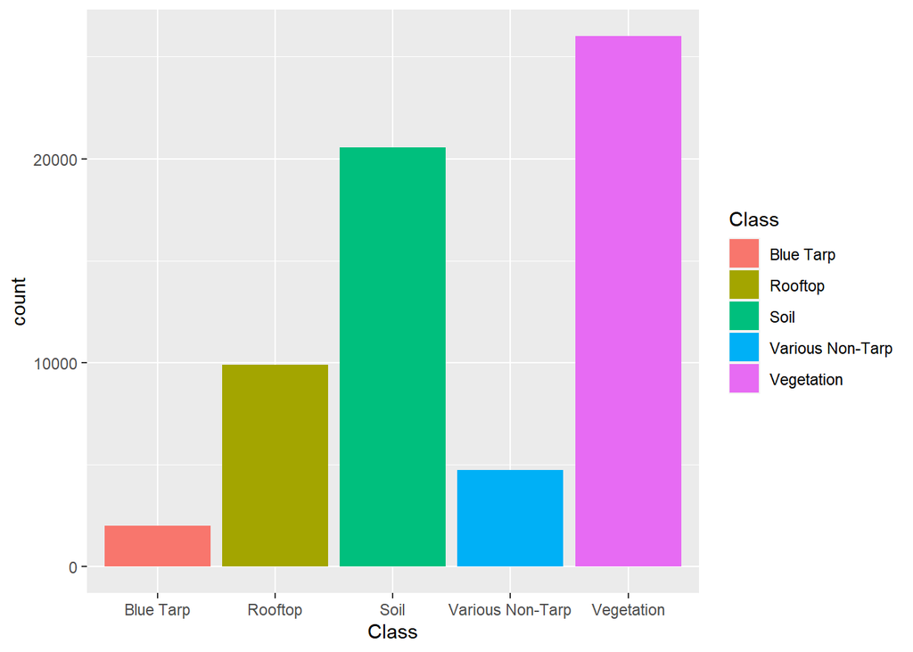

From the above bar graph & class summary,we can see that the multi-class training dataset is dataset is highly imbalanced.

However we are interested in only predicting **BlueTarp** or **NotBlueTarp** so transforming multi-class **Class** variable to binary class variable.

### 3.4.5 Transform train_data

```r
# ref: transform
train_data <-
  mutate(train_data, Class = ifelse(train_data$Class == "Blue Tarp",
                                   "BlueTarp",
                                   "NotBlueTarp"))
# factorize
train_data <-
  mutate(train_data , Class =
           factor(train_data$Class, levels=c('BlueTarp', 'NotBlueTarp')))


# contrasts of Class variable
contrasts(train_data$Class)
```

```
##             NotBlueTarp
## BlueTarp              0
## NotBlueTarp           1
```

The in-place transformed Class columns is factorized again.

### 3.4.6 Summary transformed train_data

```r
summary(train_data)
```

```
##          Class            Red          Green            Blue
##  BlueTarp   : 2022   Min.   : 48   Min.   : 48.0   Min.   : 44.0
##  NotBlueTarp:61219   1st Qu.: 80   1st Qu.: 78.0   1st Qu.: 63.0
##                      Median :163   Median :148.0   Median :123.0
##                      Mean   :163   Mean   :153.7   Mean   :125.1
##                      3rd Qu.:255   3rd Qu.:226.0   3rd Qu.:181.0
##                      Max.   :255   Max.   :255.0   Max.   :255.0
```

Now, the training dataset has two only classes **BlueTarp**, **NotBlueTarp** required for our study.

### 3.4.7 Class distribution transformed train_data

```r
class_summary_by_precentage(train_data)
```

```
##             frequency percentage
## BlueTarp         2022   3.197293
## NotBlueTarp     61219  96.802707
```

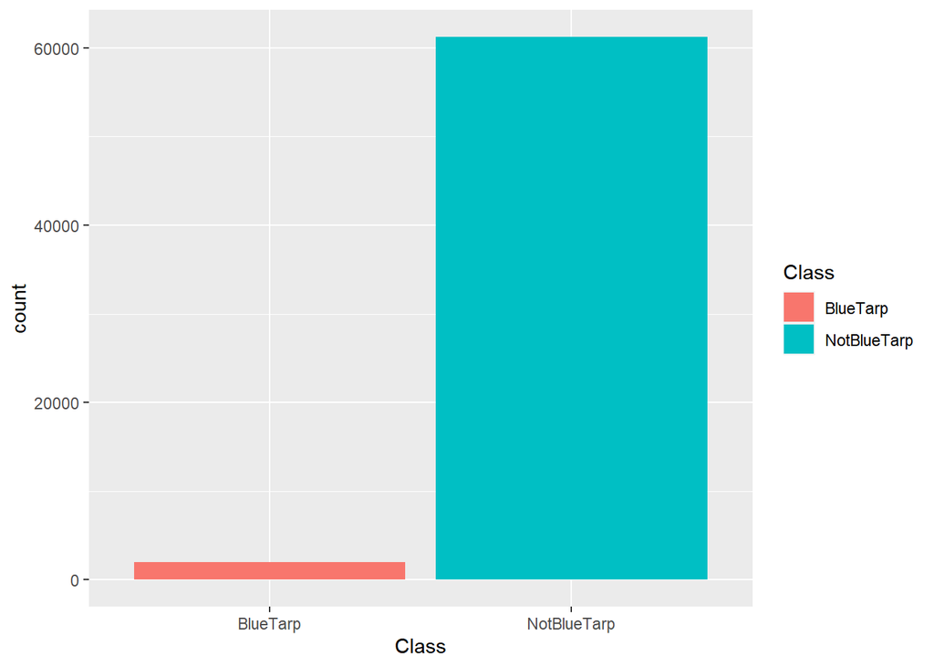

### 3.4.8 Boxplot transformed train_data

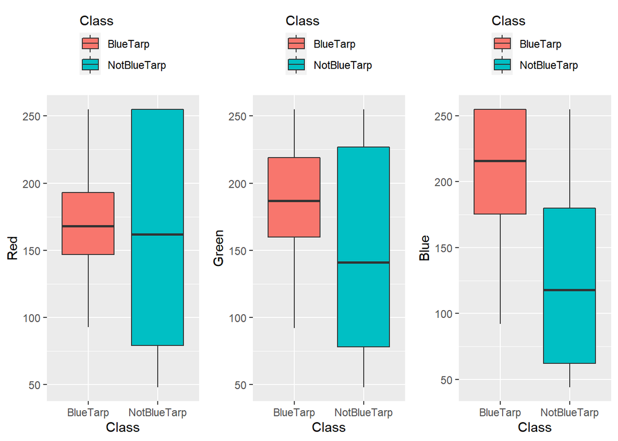

```r
plot_boxplots_byclass(train_data)
```

From the above shown transformed dataset class summary and box plot, we can conclude that our data set is highly imbalanced between two classes with only about 3.20% of observations representing the **BlueTarps**. It is a minority positive class we are interested in predicting.

Next, we will explore the holdout out dataset.

## 3.5 Holdout Data

### 3.5.1 Peek at holdout_data

```r
str(holdout_data)
```

```
## 'data.frame':    2004177 obs. of  4 variables:
##  $ Class: Factor w/ 2 levels "BlueTarp","NotBlueTarp": 2 2 2 2 2 2 2 2 2 2 ...
##  $ Red  : int  104 101 103 107 109 103 100 98 97 99 ...
##  $ Green: int  89 80 87 93 99 73 79 70 73 79 ...
##  $ Blue : int  63 60 69 72 68 53 56 51 56 61 ...
```

```r
head(holdout_data)
```

|  | Class | Red | Green | Blue |
| --- | --- | --- | --- | --- |
| 1 | NotBlueTarp | 104 | 89 | 63 |
| 2 | NotBlueTarp | 101 | 80 | 60 |
| 3 | NotBlueTarp | 103 | 87 | 69 |
| 4 | NotBlueTarp | 107 | 93 | 72 |
| 5 | NotBlueTarp | 109 | 99 | 68 |
| 6 | NotBlueTarp | 103 | 73 | 53 |

### 3.5.2 Check missing data in holdout_data

```r
if (sum(is.na(holdout_data)) > 0) {
  holdout_data <- na.omit(holdout_data)
} else {
  print("no missing values in the holdout dataset")
}
```

```
## [1] "no missing values in the holdout dataset"
```

The holdout_data the same three features are integer values and does not have any missing data.

### 3.5.3 Summary holdout_data

```r
summary(holdout_data)
```

```
##          Class              Red            Green            Blue
##  BlueTarp   :  14480   Min.   : 27.0   Min.   : 28.0   Min.   : 25.00
##  NotBlueTarp:1989697   1st Qu.: 76.0   1st Qu.: 71.0   1st Qu.: 55.00
##                        Median :107.0   Median : 91.0   Median : 66.00
##                        Mean   :118.3   Mean   :105.4   Mean   : 82.36
##                        3rd Qu.:139.0   3rd Qu.:117.0   3rd Qu.: 88.00
##                        Max.   :255.0   Max.   :255.0   Max.   :255.00
```

### 3.5.4 Class distribution holdout_data

```r
class_summary_by_precentage(holdout_data)
```

```
##             frequency percentage
## BlueTarp        14480  0.7224911
## NotBlueTarp   1989697 99.2775089
```

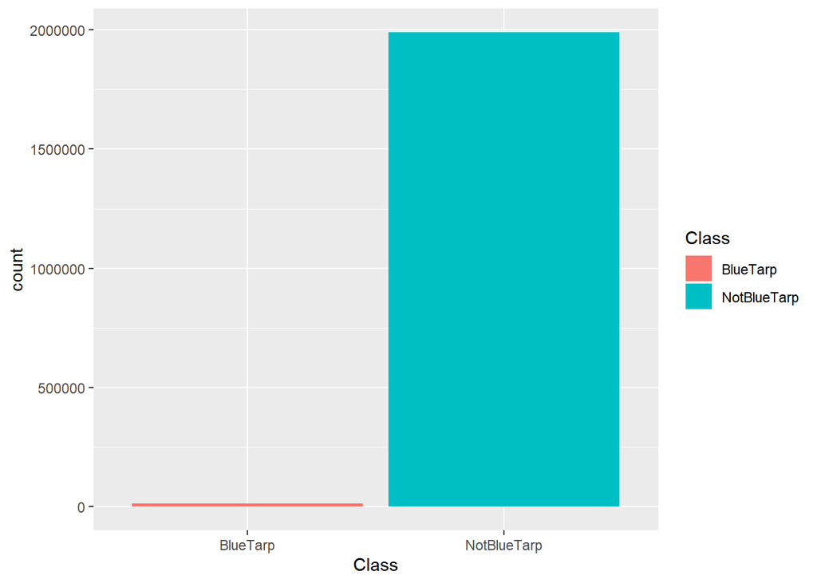

### 3.5.5 Holdout_data boxplot

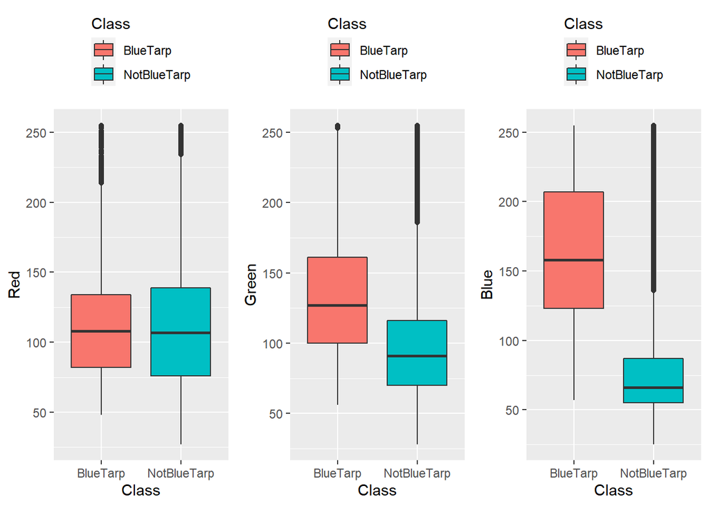

```r
plot_boxplots_byclass(holdout_data)
```

The training dataset has about 3.20% of the obeservations as **BlueTarp**, we have already confirmed that the training data is highly imbalanced.

We see that holdout dataset is also highly imbalanced. The **BlueTarp** observations are only 0.72% and the **NotBlueTarp** class observations make up 99.28% of the holdout data.

```r
### train_data density plot
# density plots for each variable by Class value
#scales <- list(x=list(relation="free"), y=list(relation="free"))
#featurePlot(x=train_data[,2:4], y=train_data$Class, plot="density", #scales=scales,
#            adjust = 1.5,
#            pch = "|",
#            layout = c(3, 1),
#            auto.key = list(columns = 3))
```

# 4 Evaluate Algorithms

In part2 of this project, we will include Random forest and SVM models in addition the KNN, LDQ, QDA and Logistic Regression studied in part1 of the project.

## 4.1 Test harness

```r
# ref: test-harness
fitControl <- trainControl(
  method = 'cv',            # k-fold cross validation
  number = 10,              # number of folds
  savePredictions = 'final',# saves predictions for optimal tuning parameter
  classProbs = TRUE,      # should class probabilities be computed and returned
  #summaryFunction =
        #twoClassSummary,   # results summary function
  returnResamp = 'all',     # indicator amount resampled summary metrics -
  allowParallel = TRUE
)
```

## 4.2 Baseline Algorithms

We do not know which algorithm We will first explore each algorithm’s baseline performance before applying the **hyper parameter tuning** to each learning method. We make observations, and then we will tune and potentially try variants of each of the learning parameters made available via the R Caret package.

### 4.2.1 Fit baseline models

```r
# KNN
knn_fit_base <- fit_model(train_data,"knn",baseline=TRUE)
knn_fit_base
```

```
## k-Nearest Neighbors
##
## 63241 samples
##     3 predictor
##     2 classes: 'BlueTarp', 'NotBlueTarp'
##
## Pre-processing: centered (3), scaled (3)
## Resampling: Cross-Validated (10 fold)
## Summary of sample sizes: 56917, 56917, 56917, 56917, 56917, 56917, ...
## Resampling results:
##
##   Accuracy   Kappa
##   0.9971379  0.9539369
##
## Tuning parameter 'k' was held constant at a value of 5
```

```r
# LDA
lda_fit_base <- fit_model(train_data,"lda", baseline=TRUE)
lda_fit_base
```

```
## Linear Discriminant Analysis
##
## 63241 samples
##     3 predictor
##     2 classes: 'BlueTarp', 'NotBlueTarp'
##
## Pre-processing: centered (3), scaled (3)
## Resampling: Cross-Validated (10 fold)
## Summary of sample sizes: 56917, 56917, 56917, 56917, 56917, 56917, ...
## Resampling results:
##
##   Accuracy   Kappa
##   0.9839503  0.7529645
```

```r
# QDA
qda_fit_base <- fit_model(train_data,"qda", baseline=TRUE)
qda_fit_base
```

```
## Quadratic Discriminant Analysis
##
## 63241 samples
##     3 predictor
##     2 classes: 'BlueTarp', 'NotBlueTarp'
##
## Pre-processing: centered (3), scaled (3)
## Resampling: Cross-Validated (10 fold)
## Summary of sample sizes: 56917, 56917, 56917, 56917, 56917, 56917, ...
## Resampling results:
##
##   Accuracy   Kappa
##   0.9945921  0.9056195
```

```r
# Logistic Regression
lr_fit_base <- fit_model(train_data,"glm", baseline=TRUE)
lr_fit_base
```

```
## Generalized Linear Model
##
## 63241 samples
##     3 predictor
##     2 classes: 'BlueTarp', 'NotBlueTarp'
##
## Pre-processing: centered (3), scaled (3)
## Resampling: Cross-Validated (10 fold)
## Summary of sample sizes: 56917, 56917, 56917, 56917, 56917, 56917, ...
## Resampling results:
##
##   Accuracy  Kappa
##   0.995272  0.9204337
```

```r
# SVM
svm_fit_base <- fit_model(train_data,"svmRadial", baseline=TRUE)
svm_fit_base
```

```
## Support Vector Machines with Radial Basis Function Kernel
##
## 63241 samples
##     3 predictor
##     2 classes: 'BlueTarp', 'NotBlueTarp'
##
## Pre-processing: centered (3), scaled (3)
## Resampling: Cross-Validated (10 fold)
## Summary of sample sizes: 56917, 56917, 56917, 56917, 56917, 56917, ...
## Resampling results:
##
##   Accuracy   Kappa
##   0.9966161  0.9444875
##
## Tuning parameter 'sigma' was held constant at a value of 8.659444
##
## Tuning parameter 'C' was held constant at a value of 0.25
```

```r
# Random Forest
rf_fit_base <- fit_model(train_data,"rf", baseline=TRUE)
rf_fit_base
```

```
## Random Forest
##
## 63241 samples
##     3 predictor
##     2 classes: 'BlueTarp', 'NotBlueTarp'
##
## Pre-processing: centered (3), scaled (3)
## Resampling: Cross-Validated (10 fold)
## Summary of sample sizes: 56917, 56917, 56917, 56917, 56917, 56917, ...
## Resampling results:
##
##   Accuracy  Kappa
##   0.996964  0.9504531
##
## Tuning parameter 'mtry' was held constant at a value of 1
```

We can see the model summaries that the caret package can auto-tune KNN, SVM, and RF models.

### 4.2.2 Performance measures (thresh = 0.5)

```r
knn_cfm_base = get_confusion_matrix(knn_fit_base)
lda_cfm_base = get_confusion_matrix(lda_fit_base)
qda_cfm_base = get_confusion_matrix(qda_fit_base)
lr_cfm_base = get_confusion_matrix(lr_fit_base)
svm_cfm_base = get_confusion_matrix(svm_fit_base)
rf_cfm_base = get_confusion_matrix(rf_fit_base)

cfm_df_default_thres_base <-
  as.data.frame(list(
    'knn' = list.append(knn_cfm_base$overall, knn_cfm_base$byClass),
    'lda' = list.append(lda_cfm_base$overall, lda_cfm_base$byClass),
    'qda' = list.append(qda_cfm_base$overall, qda_cfm_base$byClass),
    'lr' =  list.append(lr_cfm_base$overall, lr_cfm_base$byClass),
    'svm' = list.append(svm_cfm_base$overall, svm_cfm_base$byClass),
    'rf' =  list.append(rf_cfm_base$overall,rf_cfm_base$byClass)))

knitr::kable(cfm_df_default_thres_base, digits = 4)
```

|  | knn | lda | qda | lr | svm | rf |
| --- | --- | --- | --- | --- | --- | --- |
| Accuracy | 0.9972 | 0.9840 | 0.9946 | 0.9953 | 0.9966 | 0.9969 |
| Kappa | 0.9542 | 0.7531 | 0.9057 | 0.9205 | 0.9445 | 0.9502 |
| AccuracyLower | 0.9967 | 0.9829 | 0.9940 | 0.9947 | 0.9961 | 0.9965 |
| AccuracyUpper | 0.9976 | 0.9849 | 0.9951 | 0.9958 | 0.9971 | 0.9974 |
| AccuracyNull | 0.9680 | 0.9680 | 0.9680 | 0.9680 | 0.9680 | 0.9680 |
| AccuracyPValue | 0.0000 | 0.0000 | 0.0000 | 0.0000 | 0.0000 | 0.0000 |
| McnemarPValue | 0.4123 | 0.0000 | 0.0000 | 0.0000 | 0.0000 | 0.0062 |
| Sensitivity | 0.9585 | 0.8007 | 0.8398 | 0.8853 | 0.9318 | 0.9426 |
| Specificity | 0.9984 | 0.9900 | 0.9997 | 0.9989 | 0.9988 | 0.9987 |
| Pos Pred Value | 0.9528 | 0.7257 | 0.9895 | 0.9639 | 0.9612 | 0.9612 |
| Neg Pred Value | 0.9986 | 0.9934 | 0.9947 | 0.9962 | 0.9977 | 0.9981 |
| Precision | 0.9528 | 0.7257 | 0.9895 | 0.9639 | 0.9612 | 0.9612 |
| Recall | 0.9585 | 0.8007 | 0.8398 | 0.8853 | 0.9318 | 0.9426 |
| F1 | 0.9556 | 0.7613 | 0.9085 | 0.9229 | 0.9463 | 0.9518 |
| Prevalence | 0.0320 | 0.0320 | 0.0320 | 0.0320 | 0.0320 | 0.0320 |
| Detection Rate | 0.0306 | 0.0256 | 0.0268 | 0.0283 | 0.0298 | 0.0301 |
| Detection Prevalence | 0.0322 | 0.0353 | 0.0271 | 0.0294 | 0.0310 | 0.0314 |
| Balanced Accuracy | 0.9784 | 0.8953 | 0.9197 | 0.9421 | 0.9653 | 0.9707 |

QDA is faring better than other models, without any tuning. It has a 98.95% very high precision score that minimizes false positives. This is what we desire. We can also note that KNN, SVM, and RF also have precision close to 96%, which is still very good. LDA fares poorly when it comes to precision score.

### 4.2.3 Confusion Matrix(thresh =0.5)

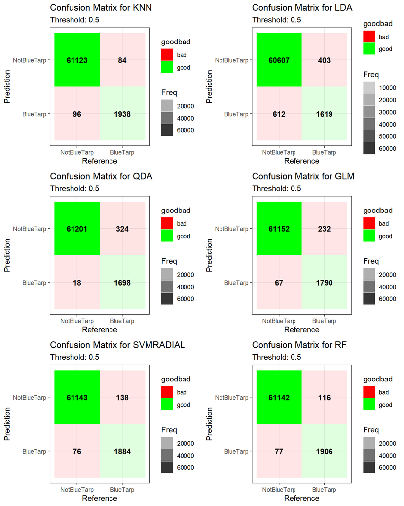

```r
cfm_knn_plot_base <- plot_confusion_matrix(knn_fit_base)

cfm_lda_plot_base <- plot_confusion_matrix(lda_fit_base)

cfm_qda_plot_base <- plot_confusion_matrix(qda_fit_base)

cfm_lr_plot_base <- plot_confusion_matrix(lr_fit_base)

cfm_svm_plot_base <- plot_confusion_matrix(svm_fit_base)

cfm_rf_plot_base <- plot_confusion_matrix(rf_fit_base)


gridExtra::grid.arrange(cfm_knn_plot_base,cfm_lda_plot_base ,cfm_qda_plot_base,
                        cfm_lr_plot_base, cfm_svm_plot_base,
                        cfm_rf_plot_base, nrow = 3 , newpage = TRUE)
```

** The baseline KNN model performs better on the training data.**

## 4.3 Tune Hyperparameters

*Hyper parameter details are documented in the functions section of this project for fit_model function.*

Next, we will fit the models with respective hyper parameters to improve the performance with our dataset.

### 4.3.1 Fit models with tuned-&-scaled-data

```r
# KNN
knn_fit <- fit_model(train_data,"knn")
knn_fit
```

```
## k-Nearest Neighbors
##
## 63241 samples
##     3 predictor
##     2 classes: 'BlueTarp', 'NotBlueTarp'
##
## Pre-processing: centered (3), scaled (3)
## Resampling: Cross-Validated (10 fold)
## Summary of sample sizes: 56917, 56917, 56917, 56917, 56917, 56917, ...
## Resampling results across tuning parameters:
##
##   k  Accuracy   Kappa
##   1  0.9968059  0.9481298
##   3  0.9972960  0.9563348
##   5  0.9971379  0.9539369
##   7  0.9970905  0.9532725
##   9  0.9972170  0.9553744
##
## Accuracy was used to select the optimal model using the largest value.
## The final value used for the model was k = 3.
```

```r
# LDA
lda_fit <- fit_model(train_data,"pda")
lda_fit
```

```
## Penalized Discriminant Analysis
##
## 63241 samples
##     3 predictor
##     2 classes: 'BlueTarp', 'NotBlueTarp'
##
## Pre-processing: centered (3), scaled (3)
## Resampling: Cross-Validated (10 fold)
## Summary of sample sizes: 56917, 56917, 56917, 56917, 56917, 56917, ...
## Resampling results across tuning parameters:
##
##   lambda   Accuracy   Kappa
##   0.00100  0.9839503  0.7529645
##   0.25075  0.9839503  0.7529645
##   0.50050  0.9839503  0.7529645
##   0.75025  0.9839503  0.7529645
##   1.00000  0.9839503  0.7529645
##
## Accuracy was used to select the optimal model using the largest value.
## The final value used for the model was lambda = 0.001.
```

```r
# QDA
qda_fit <- fit_model(train_data,"rda")
qda_fit
```

```
## Regularized Discriminant Analysis
##
## 63241 samples
##     3 predictor
##     2 classes: 'BlueTarp', 'NotBlueTarp'
##
## Pre-processing: centered (3), scaled (3)
## Resampling: Cross-Validated (10 fold)
## Summary of sample sizes: 56917, 56917, 56917, 56917, 56917, 56917, ...
## Resampling results across tuning parameters:
##
##   gamma   lambda   Accuracy   Kappa
##   0.0100  0.00100  0.9939754  0.89326616
##   0.0100  0.25075  0.9860217  0.78010864
##   0.0100  0.50050  0.9848358  0.76344398
##   0.0100  0.75025  0.9840293  0.75102135
##   0.0100  1.00000  0.9841716  0.75053060
##   0.2575  0.00100  0.9811040  0.57169193
##   0.2575  0.25075  0.9791117  0.50568050
##   0.2575  0.50050  0.9758701  0.38555297
##   0.2575  0.75025  0.9732294  0.27276989
##   0.2575  1.00000  0.9711105  0.17087987
##   0.5050  0.00100  0.9695293  0.08670904
##   0.5050  0.25075  0.9680271  0.00000000
##   0.5050  0.50050  0.9680271  0.00000000
##   0.5050  0.75025  0.9680271  0.00000000
##   0.5050  1.00000  0.9680271  0.00000000
##   0.7525  0.00100  0.9680271  0.00000000
##   0.7525  0.25075  0.9680271  0.00000000
##   0.7525  0.50050  0.9680271  0.00000000
##   0.7525  0.75025  0.9680271  0.00000000
##   0.7525  1.00000  0.9680271  0.00000000
##   1.0000  0.00100  0.9680271  0.00000000
##   1.0000  0.25075  0.9680271  0.00000000
##   1.0000  0.50050  0.9680271  0.00000000
##   1.0000  0.75025  0.9680271  0.00000000
##   1.0000  1.00000  0.9680271  0.00000000
##
## Accuracy was used to select the optimal model using the largest value.
## The final values used for the model were gamma = 0.01 and lambda = 0.001.
```

```r
# Logistic Regression
lr_fit <- fit_model(train_data,"glmnet")
lr_fit
```

```
## glmnet
##
## 63241 samples
##     3 predictor
##     2 classes: 'BlueTarp', 'NotBlueTarp'
##
## Pre-processing: centered (3), scaled (3)
## Resampling: Cross-Validated (10 fold)
## Summary of sample sizes: 56917, 56917, 56917, 56917, 56917, 56917, ...
## Resampling results across tuning parameters:
##
##   alpha  lambda        Accuracy   Kappa
##   0.10   8.322155e-05  0.9936592  0.88696777
##   0.10   8.322155e-04  0.9875239  0.75093679
##   0.10   8.322155e-03  0.9685963  0.03376692
##   0.55   8.322155e-05  0.9942126  0.89855396
##   0.55   8.322155e-04  0.9894688  0.79699941
##   0.55   8.322155e-03  0.9704464  0.13652851
##   1.00   8.322155e-05  0.9952088  0.91837192
##   1.00   8.322155e-04  0.9932164  0.87782884
##   1.00   8.322155e-03  0.9806929  0.55849371
##
## Accuracy was used to select the optimal model using the largest value.
## The final values used for the model were alpha = 1 and lambda = 8.322155e-05.
```

```r
# SVM
svm_fit <- fit_model(train_data,"svmRadial")
svm_fit
```

```
## Support Vector Machines with Radial Basis Function Kernel
##
## 63241 samples
##     3 predictor
##     2 classes: 'BlueTarp', 'NotBlueTarp'
##
## Pre-processing: centered (3), scaled (3)
## Resampling: Cross-Validated (10 fold)
## Summary of sample sizes: 56917, 56917, 56917, 56917, 56917, 56917, ...
## Resampling results across tuning parameters:
##
##   C     Accuracy   Kappa
##   0.25  0.9965845  0.9439949
##   0.50  0.9968691  0.9486300
##   1.00  0.9969798  0.9504466
##
## Tuning parameter 'sigma' was held constant at a value of 8.659444
## Accuracy was used to select the optimal model using the largest value.
## The final values used for the model were sigma = 8.659444 and C = 1.
```

```r
# Random Forest
rf_fit <- fit_model(train_data,"rf")
rf_fit
```

```
## Random Forest
##
## 63241 samples
##     3 predictor
##     2 classes: 'BlueTarp', 'NotBlueTarp'
##
## Pre-processing: centered (3), scaled (3)
## Resampling: Cross-Validated (10 fold)
## Summary of sample sizes: 56917, 56917, 56917, 56917, 56917, 56917, ...
## Resampling results across tuning parameters:
##
##   mtry  Accuracy   Kappa
##   1     0.9969324  0.9499193
##   2     0.9969324  0.9500585
##   3     0.9967426  0.9470418
##   4     0.9967584  0.9472917
##   5     0.9967900  0.9478740
##
## Accuracy was used to select the optimal model using the largest value.
## The final value used for the model was mtry = 2.
```

### 4.3.2 Model Accuracy Vs. tuning parameter plots

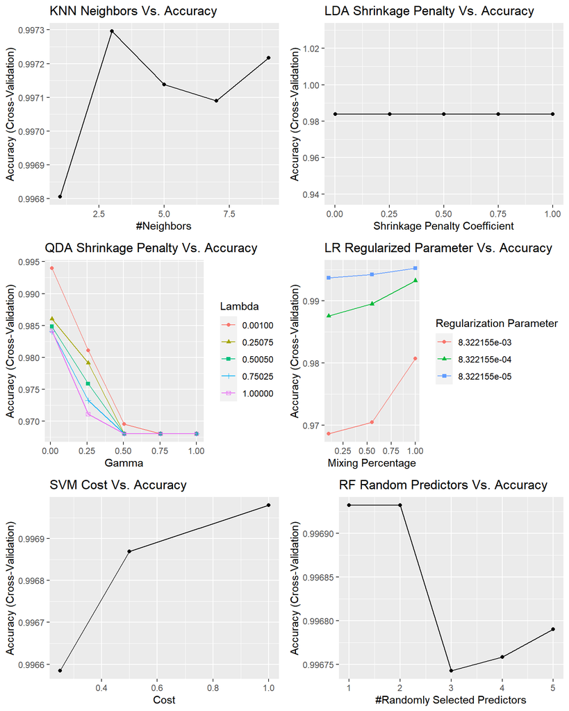

```r
g1 <- ggplot(knn_fit) +
      ggtitle(label = 'KNN Neighbors Vs. Accuracy')

g2 <- ggplot(lda_fit)+
      ggtitle(label = 'LDA Shrinkage Penalty Vs. Accuracy')

g3 <- ggplot(qda_fit)+
      ggtitle(label = 'QDA Shrinkage Penalty Vs. Accuracy')

g4 <- ggplot(lr_fit)+
      ggtitle(label = 'LR Regularized Parameter Vs. Accuracy')

g5 <- ggplot(svm_fit)+
      ggtitle(label = 'SVM Cost Vs. Accuracy')

g6 <- ggplot(rf_fit)+
      ggtitle(label = 'RF Random Predictors Vs. Accuracy')


gridExtra::grid.arrange(g1,g2,g3,g4,g5,g6, nrow = 3 , newpage = TRUE)
```

### 4.3.3 Precision-Recall curves

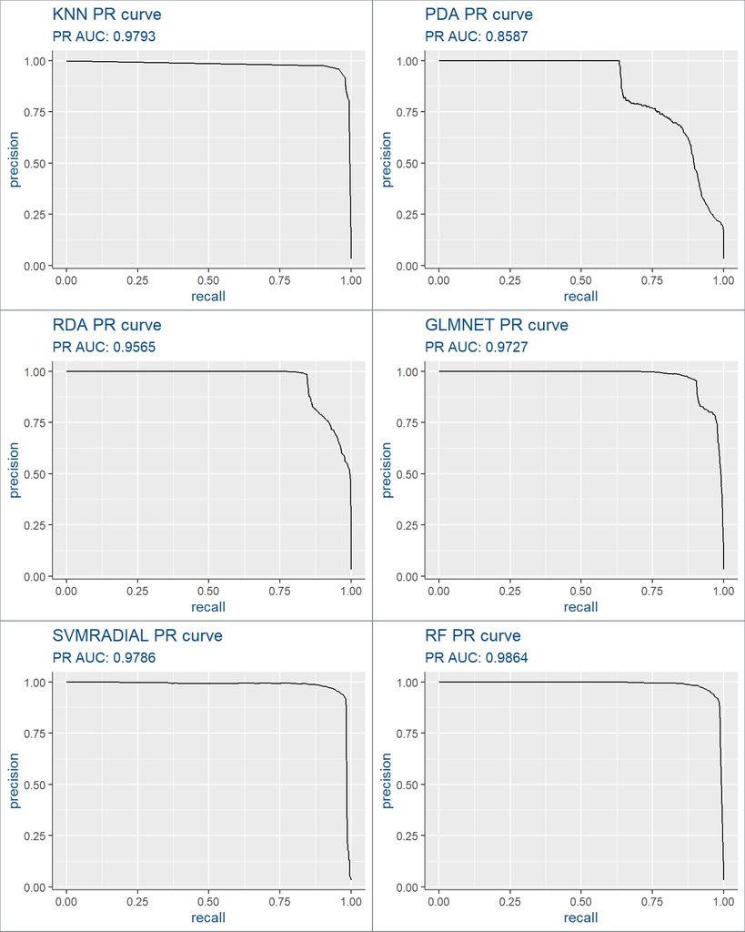

```r
# polt p-r curve for all models
knn_prcurve <- plot_pr_curve(knn_fit)
lda_prcurve <- plot_pr_curve(lda_fit)
qda_prcurve <- plot_pr_curve(qda_fit)
lr_prcurve <- plot_pr_curve(lr_fit)
svm_prcurve <- plot_pr_curve(svm_fit)
rf_prcurve <- plot_pr_curve(rf_fit)

library(gridExtra)
gridExtra::grid.arrange(knn_prcurve,lda_prcurve ,qda_prcurve, lr_prcurve,
                        svm_prcurve,rf_prcurve, nrow = 3)
```

The PR-curves are used to draw out relation between true positive rate (precision) and the true positives predicted by the model, as noted in the function plot_pr_curve is used particularly when dataset has highly imbalanced binary classes.

**Note: GLMNET is the implementation for Logistic regression**

Now, lets examine the sampling uncertainty in k-folds. Our goal in this project is predict BlueTarps which is a minority class in the imbalanced dataset. So model Accuracy is not a good measure for any model.

Note : PR AUC is calculated and displayed on PR curves

### 4.3.4 Sampling uncertainty in k-folds

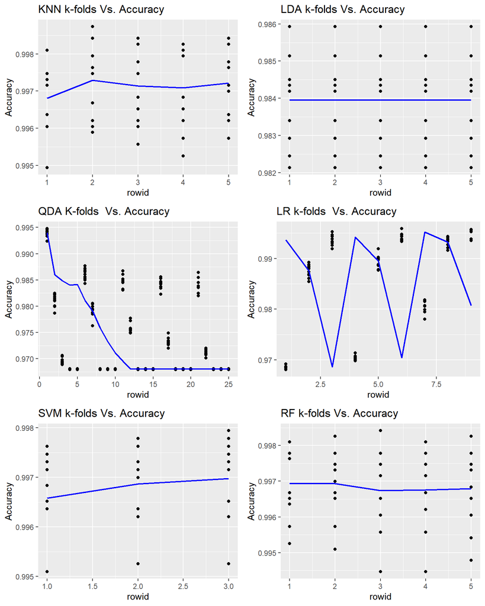

```r
plot_kfolds_roc <- function (classifier){
  myplot<- classifier$resample %>%
    dplyr::group_split(Resample) %>%
    purrr::map(rowid_to_column) %>%
    dplyr::bind_rows() %>%
    ggplot(aes(rowid, Accuracy)) + geom_point() +
    geom_smooth(formula='y~x', method='loess', span=.03) +
    geom_line(classifier$results, mapping=aes(seq_along(Accuracy), Accuracy),
    size=0.8, color='blue')
  return (myplot)
}

g1 <- plot_kfolds_roc(knn_fit) +
      ggtitle(label = 'KNN k-folds Vs. Accuracy')

g2 <- plot_kfolds_roc(lda_fit) +
      ggtitle(label = 'LDA k-folds Vs. Accuracy')

g3 <- plot_kfolds_roc(qda_fit) +
      ggtitle(label = 'QDA K-folds  Vs. Accuracy')

g4 <- plot_kfolds_roc(lr_fit) +
      ggtitle(label = 'LR k-folds  Vs. Accuracy')

g5 <- plot_kfolds_roc(svm_fit) +
      ggtitle(label = 'SVM k-folds Vs. Accuracy')

g6 <- plot_kfolds_roc(rf_fit) +
      ggtitle(label = 'RF k-folds Vs. Accuracy')

gridExtra::grid.arrange(g1, g2, g3, g4, g5, g6, nrow = 3 , newpage = TRUE)
```

The above shown plot help us appreciate the variability in the model **accuracy** across all 10-folds.

Next, let us examine and understand the uncertainty in k-folds.

```r
classifiers <- list(knn_fit, lda_fit, qda_fit, lr_fit, svm_fit, rf_fit)
uncertainty_df <- get_uncertainty_measures(classifiers)

knitr::kable(uncertainty_df, digits = 4)
```

| method | mean-sensitivity | sdev | fold1 | fold2 | fold3 | fold4 | fold5 | fold6 | fold7 | fold8 | fold9 | fold10 |
| --- | --- | --- | --- | --- | --- | --- | --- | --- | --- | --- | --- | --- |
| knn | 0.9560 | 0.0162 | 0.9356 | 0.9505 | 0.9752 | 0.9505 | 0.9752 | 0.9406 | 0.9752 | 0.9409 | 0.9458 | 0.9703 |
| pda | 0.8007 | 0.0275 | 0.7574 | 0.8069 | 0.7970 | 0.7723 | 0.8020 | 0.7921 | 0.7822 | 0.8473 | 0.8374 | 0.8119 |
| rda | 0.8160 | 0.0223 | 0.7673 | 0.8119 | 0.8168 | 0.7970 | 0.8218 | 0.8168 | 0.8119 | 0.8473 | 0.8325 | 0.8366 |
| glmnet | 0.8724 | 0.0199 | 0.8267 | 0.8812 | 0.8762 | 0.8713 | 0.8812 | 0.8564 | 0.8861 | 0.8966 | 0.8621 | 0.8861 |
| svmRadial | 0.9387 | 0.0218 | 0.8960 | 0.9307 | 0.9406 | 0.9109 | 0.9604 | 0.9455 | 0.9554 | 0.9557 | 0.9310 | 0.9604 |
| rf | 0.9426 | 0.0176 | 0.9208 | 0.9406 | 0.9505 | 0.9158 | 0.9752 | 0.9307 | 0.9505 | 0.9507 | 0.9360 | 0.9554 |

similarly looking at the std. dev for sensitivity for the models, we can examine and understand the uncertainty in prediction accuracy.

The plots also demonstrate this show above helps us understand the variability of accuracy for each of the 10 k-folds.

Note: ‘pda’ and ‘rda’ can be tuned in caret applying the shrinkage penalty lambda, rda also uses gamma as tuning parameter.

### 4.3.5 Performance measures(params tuned & thresh = 0.5)

```r
knn_cfm = get_confusion_matrix(knn_fit)
lda_cfm = get_confusion_matrix(lda_fit)
qda_cfm = get_confusion_matrix(qda_fit)
lr_cfm = get_confusion_matrix(lr_fit)
svm_cfm = get_confusion_matrix(svm_fit)
rf_cfm = get_confusion_matrix(rf_fit)

cfm_df_default_thres <-
  as.data.frame(list('knn' = list.append(knn_cfm$overall, knn_cfm$byClass),
                     'lda' = list.append(lda_cfm$overall, lda_cfm$byClass),
                     'qda' = list.append(qda_cfm$overall, qda_cfm$byClass),
                     'lr' =  list.append(lr_cfm$overall, lr_cfm$byClass),
                     'svm' = list.append(svm_cfm$overall, svm_cfm$byClass),
                     'rf' =  list.append(rf_cfm$overall,rf_cfm$byClass)))
knitr::kable(cfm_df_default_thres, digits = 4)
```

|  | knn | lda | qda | lr | svm | rf |
| --- | --- | --- | --- | --- | --- | --- |
| Accuracy | 0.9973 | 0.9840 | 0.9940 | 0.9952 | 0.9970 | 0.9969 |
| Kappa | 0.9558 | 0.7531 | 0.8934 | 0.9184 | 0.9505 | 0.9500 |
| AccuracyLower | 0.9968 | 0.9829 | 0.9933 | 0.9946 | 0.9965 | 0.9965 |
| AccuracyUpper | 0.9977 | 0.9849 | 0.9946 | 0.9957 | 0.9974 | 0.9973 |
| AccuracyNull | 0.9680 | 0.9680 | 0.9680 | 0.9680 | 0.9680 | 0.9680 |
| AccuracyPValue | 0.0000 | 0.0000 | 0.0000 | 0.0000 | 0.0000 | 0.0000 |
| McnemarPValue | 0.8791 | 0.0000 | 0.0000 | 0.0000 | 0.0001 | 0.0120 |
| Sensitivity | 0.9580 | 0.8007 | 0.8160 | 0.8724 | 0.9387 | 0.9431 |
| Specificity | 0.9986 | 0.9900 | 0.9999 | 0.9993 | 0.9989 | 0.9987 |
| Pos Pred Value | 0.9565 | 0.7257 | 0.9946 | 0.9751 | 0.9659 | 0.9602 |
| Neg Pred Value | 0.9986 | 0.9934 | 0.9940 | 0.9958 | 0.9980 | 0.9981 |
| Precision | 0.9565 | 0.7257 | 0.9946 | 0.9751 | 0.9659 | 0.9602 |
| Recall | 0.9580 | 0.8007 | 0.8160 | 0.8724 | 0.9387 | 0.9431 |
| F1 | 0.9573 | 0.7613 | 0.8965 | 0.9209 | 0.9521 | 0.9516 |
| Prevalence | 0.0320 | 0.0320 | 0.0320 | 0.0320 | 0.0320 | 0.0320 |
| Detection Rate | 0.0306 | 0.0256 | 0.0261 | 0.0279 | 0.0300 | 0.0302 |
| Detection Prevalence | 0.0320 | 0.0353 | 0.0262 | 0.0286 | 0.0311 | 0.0314 |
| Balanced Accuracy | 0.9783 | 0.8953 | 0.9079 | 0.9358 | 0.9688 | 0.9709 |

Note: In PDF the 10th fold gets truncated due, all columns render in HTML.

### 4.3.6 Confusion Matrix(params tuned & thresh = 0.5)

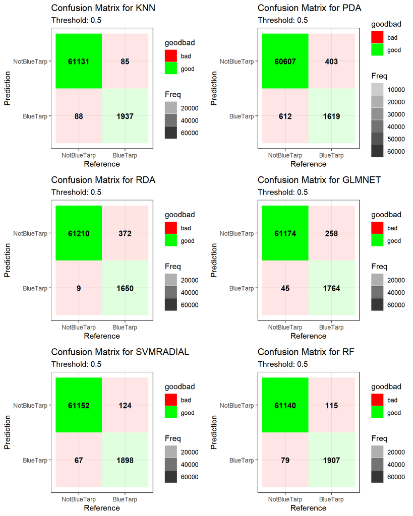

```r
cfm_knn_plot <- plot_confusion_matrix(knn_fit)

cfm_lda_plot <- plot_confusion_matrix(lda_fit)

cfm_qda_plot <- plot_confusion_matrix(qda_fit)

cfm_lr_plot <- plot_confusion_matrix(lr_fit)

cfm_svm_plot <- plot_confusion_matrix(svm_fit)

cfm_rf_plot <- plot_confusion_matrix(rf_fit)


gridExtra::grid.arrange(cfm_knn_plot,cfm_lda_plot ,cfm_qda_plot, cfm_lr_plot,
                        cfm_svm_plot,cfm_rf_plot, nrow = 3 , newpage = TRUE)
```

When we carefully examine each model’s metrics, we can see that KNN, SVM, and RF models fare better.

Note: From ‘rda’ a extension of QDA was used and in place of ‘lda’, the ‘pda’ model was used for the purpose of tuning the models from caret.

Next, we compute the best threshold. Our dataset is highly imbalanced, and since we are interested in predicting the classes **BlueTarp** and **NotBlueTarp**, and **BuleTarp** is minority & positive class. Since we are want to reach as many people as possible with food and water, we want to minimize false-negatives as possible (BlueTarp incorrectly identified as NotBlueTarp).

**Finding Best Threshold Explained:**

We know that the dataset is highly imbalanced. The *BlueTarp* is a minority positive class. The project’s goal is to get food and aid to people sheltering in a temporary shelter (*Blue Tarp*). So we want to minimize false-positives first and get the aid to as many people as possible, So we choose to minimize false positives and decided to use the f0.5- measure.

We know that **precision** minimizes the false positives, focusing on the model’s overall correct positive predictions. And the **recall** minimizes the false negatives, focusing on the model’s true positive predictions.

Both metrics have a value between 0 and 1. Choosing *precision* or *recall* to find the best threshold for a model is not easy and can be confusing. Instead, *F-measure (* that combines both *precision* and *recall*) can be used, it balances precision and recall. However, when we want to use relative importance to minimizing false positives *or* false negatives, *Fbeat-measure* - the harmonic mean of controlled by $\beta$ is a variation of *F-measure*.

$$F_\beta = { (1+ \beta^2) * precision * recall } / { \beta^2 * precision * recall }$$

The $\beta$ value of 2 is often referred to as the f2-measure, puts more emphasis on recall (minimizes false negatives) vs. the value of 1 puts equal importance on both precision and recall, and finally, a value of 0.5 puts more emphasis on precision versus recall (minimizes false positives).

### 4.3.7 Compute Best threshold

```r
knn_best_thres = get_best_threshold_from_pr_curve(knn_fit)
```

```
## [1] "knn best threshold: 0.6667"
```

```r
lda_best_thres = get_best_threshold_from_pr_curve(lda_fit)
```

```
## [1] "pda best threshold: 0.9927"
```

```r
qda_best_thres = get_best_threshold_from_pr_curve(qda_fit)
```

```
## [1] "rda best threshold: 0.2931"
```

```r
lr_best_thres = get_best_threshold_from_pr_curve(lr_fit)
```

```
## [1] "glmnet best threshold: 0.2491"
```

```r
svm_best_thres = get_best_threshold_from_pr_curve(svm_fit)
```

```
## [1] "svmRadial best threshold: 0.0365"
```

```r
rf_best_thres = get_best_threshold_from_pr_curve(rf_fit)
```

```
## [1] "rf best threshold: 0.434"
```

### 4.3.8 Performance measures(params tuned & best thres)

```r
knn_cfm_thresh = get_confusion_matrix(knn_fit, knn_best_thres)
knn.fdr <- fdr(knn_cfm_thresh$table)


lda_cfm_thresh = get_confusion_matrix(lda_fit, lda_best_thres)
lda.fdr <- fdr(lda_cfm_thresh$table)

qda_cfm_thresh = get_confusion_matrix(qda_fit, qda_best_thres)
qda.fdr <- fdr(qda_cfm_thresh$table)


lr_cfm_thresh = get_confusion_matrix(lr_fit, lr_best_thres)
lr.fdr <- fdr(lr_cfm_thresh$table)

svm_cfm_thresh = get_confusion_matrix(svm_fit, svm_best_thres)
svm.fdr <- fdr(svm_cfm_thresh$table)

rf_cfm_thresh = get_confusion_matrix(rf_fit, rf_best_thres)
rf.fdr <- fdr(rf_cfm_thresh$table)

best_thres_metrics_df <-
  as.data.frame(list('knn' = list.append(knn_cfm_thresh$overall,
                                    knn_cfm_thresh$byClass , "FDR" = knn.fdr),
                     'lda' = list.append(lda_cfm_thresh$overall,
                                    lda_cfm_thresh$byClass, "FDR" = lda.fdr),
                     'qda' = list.append(qda_cfm_thresh$overall,
                                    qda_cfm_thresh$byClass,"FDR" = qda.fdr),
                     'lr' =  list.append(lr_cfm_thresh$overall,
                                    lr_cfm_thresh$byClass, "FDR" = lr.fdr),
                     'svm' = list.append(svm_cfm_thresh$overall,
                                    svm_cfm_thresh$byClass, "FDR" = svm.fdr),
                     'rf' =  list.append(rf_cfm_thresh$overall,
                                    rf_cfm_thresh$byClass,  "FDR" = rf.fdr)))
knitr::kable(best_thres_metrics_df, digits = 4)
```

|  | knn | lda | qda | lr | svm | rf |
| --- | --- | --- | --- | --- | --- | --- |
| Accuracy | 0.9973 | 0.9883 | 0.9946 | 0.9956 | 0.9971 | 0.9970 |
| Kappa | 0.9562 | 0.7706 | 0.9068 | 0.9267 | 0.9536 | 0.9522 |
| AccuracyLower | 0.9969 | 0.9874 | 0.9940 | 0.9950 | 0.9966 | 0.9966 |
| AccuracyUpper | 0.9977 | 0.9891 | 0.9952 | 0.9961 | 0.9975 | 0.9975 |
| AccuracyNull | 0.9680 | 0.9680 | 0.9680 | 0.9680 | 0.9680 | 0.9680 |
| AccuracyPValue | 0.0000 | 0.0000 | 0.0000 | 0.0000 | 0.0000 | 0.0000 |
| McnemarPValue | 0.6464 | 0.0000 | 0.0000 | 0.0000 | 0.0000 | 0.7699 |
| Sensitivity | 0.9560 | 0.6350 | 0.8452 | 0.9050 | 0.9738 | 0.9525 |
| Specificity | 0.9987 | 1.0000 | 0.9996 | 0.9986 | 0.9978 | 0.9985 |
| Pos Pred Value | 0.9593 | 0.9984 | 0.9844 | 0.9541 | 0.9372 | 0.9549 |
| Neg Pred Value | 0.9985 | 0.9881 | 0.9949 | 0.9969 | 0.9991 | 0.9984 |
| Precision | 0.9593 | 0.9984 | 0.9844 | 0.9541 | 0.9372 | 0.9549 |
| Recall | 0.9560 | 0.6350 | 0.8452 | 0.9050 | 0.9738 | 0.9525 |
| F1 | 0.9576 | 0.7763 | 0.9095 | 0.9289 | 0.9551 | 0.9537 |
| Prevalence | 0.0320 | 0.0320 | 0.0320 | 0.0320 | 0.0320 | 0.0320 |
| Detection Rate | 0.0306 | 0.0203 | 0.0270 | 0.0289 | 0.0311 | 0.0305 |
| Detection Prevalence | 0.0319 | 0.0203 | 0.0275 | 0.0303 | 0.0332 | 0.0319 |
| Balanced Accuracy | 0.9773 | 0.8175 | 0.9224 | 0.9518 | 0.9858 | 0.9755 |
| FDR | 0.0013 | 0.0000 | 0.0004 | 0.0014 | 0.0022 | 0.0015 |

### 4.3.9 Confusion matrix(params tuned & best thres)

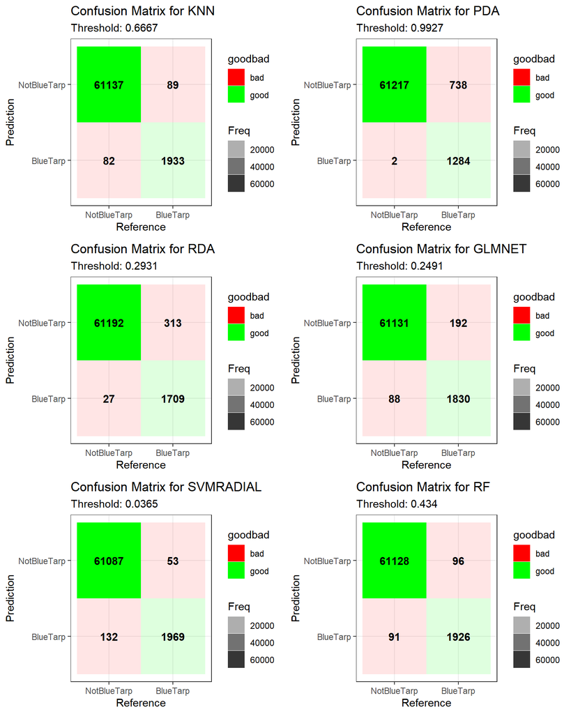

```r
knn_cfm_plot_thresh <- plot_confusion_matrix(knn_fit, knn_best_thres)


lda_cfm_plot_thresh <- plot_confusion_matrix(lda_fit, lda_best_thres)


qda_cfm_plot_thresh <- plot_confusion_matrix(qda_fit, qda_best_thres)


lr_cfm_plot_thresh <- plot_confusion_matrix(lr_fit, lr_best_thres)

svm_cfm_plot_thresh <- plot_confusion_matrix(svm_fit, svm_best_thres)

rf_cfm_plot_thresh <- plot_confusion_matrix(rf_fit, rf_best_thres)


gridExtra::grid.arrange(knn_cfm_plot_thresh,lda_cfm_plot_thresh ,
                        qda_cfm_plot_thresh, lr_cfm_plot_thresh,
                        svm_cfm_plot_thresh, rf_cfm_plot_thresh, nrow = 3)
```

## 4.4 Make Predictions

Next, we will do a similar analysis on the holdout data using the hyper parameter tuned fitted models.

### 4.4.1 Predict on holdout data

```r
knn_holdout_prob <- predict(knn_fit, holdout_data, type="prob")
lda_holdout_prob <- predict(lda_fit, holdout_data, type="prob")
qda_holdout_prob <- predict(qda_fit, holdout_data, type="prob")
lr_holdout_prob <- predict(lr_fit, holdout_data, type="prob")
svm_holdout_prob <- predict(svm_fit, holdout_data, type="prob")
rf_holdout_prob <- predict(rf_fit, holdout_data, type="prob")
```

### 4.4.2 Holdout data PR-ROC curve & PR-AUC

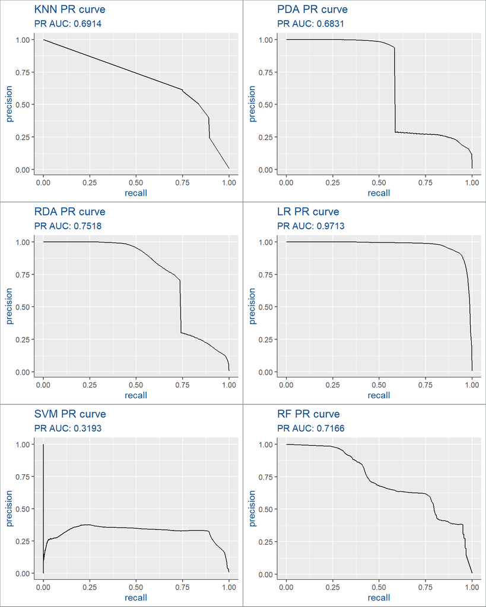

```r
# compute and plot pr-roc and pr-auc
knn_ho_pr_curve <- holdout_data_plot_pr_curve(knn_holdout_prob, 'knn')
lda_ho_pr_curve <- holdout_data_plot_pr_curve(lda_holdout_prob, 'pda')
qda_ho_pr_curve <- holdout_data_plot_pr_curve(qda_holdout_prob, 'rda')
lr_ho_pr_curve <- holdout_data_plot_pr_curve(lr_holdout_prob, 'lr')
svm_ho_pr_curve <- holdout_data_plot_pr_curve(svm_holdout_prob, 'svm')
rf_ho_pr_curve <- holdout_data_plot_pr_curve(rf_holdout_prob, 'rf')


gridExtra::grid.arrange(
  knn_ho_pr_curve,lda_ho_pr_curve ,qda_ho_pr_curve, lr_ho_pr_curve,
  svm_ho_pr_curve, rf_ho_pr_curve, nrow = 3)
```

### 4.4.3 ROC AUC and PR-AUC

```r
# compute roc
holdout_roc <- function (prob) {
  return (round((prob %>% roc_auc(holdout_data$Class,
                        BlueTarp , event_level='first'))[['.estimate']],4))
}

# compute auc
holdout_auc <- function (prob) {
  return (round((prob %>% pr_auc(holdout_data$Class,
                        BlueTarp, event_level='first'))[['.estimate']],4))
}

knn_ho_roc <- holdout_roc(knn_holdout_prob)
knn_ho_auc <- holdout_auc(knn_holdout_prob)

print(paste ("KNN holout data ROC AUC:", knn_ho_roc, "PR AUC:", knn_ho_auc))
```

```
## [1] "KNN holout data ROC AUC: 0.9444 PR AUC: 0.6914"
```

```r
lda_ho_roc <- holdout_roc(lda_holdout_prob)
lda_ho_auc <- holdout_auc(lda_holdout_prob)

print(paste ("LDA holout data ROC AUC:", lda_ho_roc, "PR AUC:", lda_ho_auc))
```

```
## [1] "LDA holout data ROC AUC: 0.9921 PR AUC: 0.6831"
```

```r
qda_ho_roc <- holdout_roc(qda_holdout_prob)
qda_ho_auc <- holdout_auc(qda_holdout_prob)

print(paste ("QDA holout data ROC AUC:", qda_ho_roc, "PR AUC:", qda_ho_auc))
```

```
## [1] "QDA holout data ROC AUC: 0.9924 PR AUC: 0.7518"
```

```r
lr_ho_roc <-  holdout_roc(lr_holdout_prob)
lr_ho_auc <-  holdout_auc(lr_holdout_prob)

print(paste ("LR holout data ROC AUC:", lr_ho_roc, "PR AUC:", lr_ho_auc))
```

```
## [1] "LR holout data ROC AUC: 0.9996 PR AUC: 0.9713"
```

```r
svm_ho_roc <- holdout_roc(svm_holdout_prob)
svm_ho_auc <- holdout_auc(svm_holdout_prob)

print(paste ("SVM holout data ROC AUC:", svm_ho_roc, "PR AUC:", svm_ho_auc))
```

```
## [1] "SVM holout data ROC AUC: 0.9888 PR AUC: 0.3193"
```

```r
rf_ho_roc <-  holdout_roc(rf_holdout_prob)
rf_ho_auc  <- holdout_auc(rf_holdout_prob)

print(paste ("RF holout data ROC AUC:", rf_ho_roc, "PR AUC:", rf_ho_auc))
```

```
## [1] "RF holout data ROC AUC: 0.9803 PR AUC: 0.7166"
```

Note: we will use the PR AUC to record results

### 4.4.4 Holdout data pred. perf. measures (param tuned & thres=0.5)

```r
knn_cfm_ho_dthres <- get_holdout_confusion_matrix(holdout_data$Class,
                                             knn_holdout_prob)
lda_cfm_ho_dthres <- get_holdout_confusion_matrix(holdout_data$Class,
                                             lda_holdout_prob)
qda_cfm_ho_dthres <- get_holdout_confusion_matrix(holdout_data$Class,
                                             qda_holdout_prob)
lr_cfm_ho_dthres <- get_holdout_confusion_matrix(holdout_data$Class,
                                             lr_holdout_prob)
svm_cfm_ho_dthres <- get_holdout_confusion_matrix(holdout_data$Class,
                                             svm_holdout_prob)
rf_cfm_ho_dthres <- get_holdout_confusion_matrix(holdout_data$Class,
                                             rf_holdout_prob)
knn.fdr_ho <- fdr(knn_cfm_ho_dthres$table)
lda.fdr_ho <- fdr(lda_cfm_ho_dthres$table)
qda.fdr_ho <- fdr(qda_cfm_ho_dthres$table)
lr.fdr_ho <- fdr(lr_cfm_ho_dthres$table)
svm.fdr_ho <- fdr(svm_cfm_ho_dthres$table)
rf.fdr_ho <- fdr(rf_cfm_ho_dthres$table)
best_thres_ho_dthres_df <-
  as.data.frame(
    list('knn' = list.append(knn_cfm_ho_dthres$overall,
                          knn_cfm_ho_dthres$byClass, "FDR" = knn.fdr_ho),
      'lda' = list.append(lda_cfm_ho_dthres$overall,
                          lda_cfm_ho_dthres$byClass, "FDR" = lda.fdr_ho),
      'qda' = list.append(qda_cfm_ho_dthres$overall,
                          qda_cfm_ho_dthres$byClass, "FDR" = qda.fdr_ho),
      'lr' =  list.append(lr_cfm_ho_dthres$overall,
                          lr_cfm_ho_dthres$byClass, "FDR" = lr.fdr_ho),
      'svm' = list.append(svm_cfm_ho_dthres$overall,
                          svm_cfm_ho_dthres$byClass, "FDR" = svm.fdr_ho),
      'rf' =  list.append(rf_cfm_ho_dthres$overall,
                          rf_cfm_ho_dthres$byClass, "FDR" = rf.fdr_ho)))
knitr::kable(best_thres_ho_dthres_df, digits = 4)
```

|  | knn | lda | qda | lr | svm | rf |
| --- | --- | --- | --- | --- | --- | --- |
| Accuracy | 0.9928 | 0.9817 | 0.9962 | 0.9950 | 0.9902 | 0.9935 |
| Kappa | 0.6229 | 0.3924 | 0.7169 | 0.7379 | 0.3859 | 0.6332 |
| AccuracyLower | 0.9927 | 0.9816 | 0.9961 | 0.9949 | 0.9900 | 0.9933 |
| AccuracyUpper | 0.9929 | 0.9819 | 0.9963 | 0.9951 | 0.9903 | 0.9936 |
| AccuracyNull | 0.9928 | 0.9928 | 0.9928 | 0.9928 | 0.9928 | 0.9928 |
| AccuracyPValue | 0.4590 | 1.0000 | 0.0000 | 0.0000 | 1.0000 | 0.0000 |
| McnemarPValue | 0.0000 | 0.0000 | 0.0000 | 0.0000 | 0.0000 | 0.0000 |
| Sensitivity | 0.8372 | 0.8390 | 0.6684 | 0.9847 | 0.4371 | 0.7926 |
| Specificity | 0.9939 | 0.9828 | 0.9986 | 0.9951 | 0.9942 | 0.9949 |
| Pos Pred Value | 0.5003 | 0.2618 | 0.7774 | 0.5930 | 0.3534 | 0.5316 |
| Neg Pred Value | 0.9988 | 0.9988 | 0.9976 | 0.9999 | 0.9959 | 0.9985 |
| Precision | 0.5003 | 0.2618 | 0.7774 | 0.5930 | 0.3534 | 0.5316 |
| Recall | 0.8372 | 0.8390 | 0.6684 | 0.9847 | 0.4371 | 0.7926 |
| F1 | 0.6263 | 0.3991 | 0.7188 | 0.7402 | 0.3908 | 0.6364 |
| Prevalence | 0.0072 | 0.0072 | 0.0072 | 0.0072 | 0.0072 | 0.0072 |
| Detection Rate | 0.0060 | 0.0061 | 0.0048 | 0.0071 | 0.0032 | 0.0057 |
| Detection Prevalence | 0.0121 | 0.0231 | 0.0062 | 0.0120 | 0.0089 | 0.0108 |
| Balanced Accuracy | 0.9155 | 0.9109 | 0.8335 | 0.9899 | 0.7156 | 0.8938 |
| FDR | 0.0061 | 0.0172 | 0.0014 | 0.0049 | 0.0058 | 0.0051 |

### 4.4.5 Holdout data confusion matrix(param tuned & thresh=0.5)

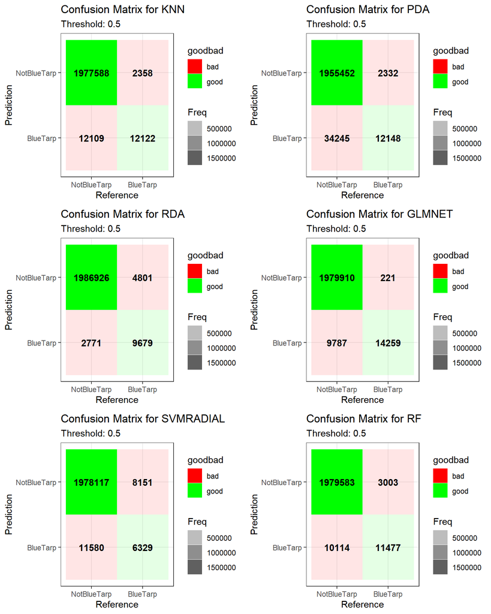

```r
knn_cfm_plot_ho_thres <- plot_holdout_confusion_matrix(holdout_data$Class,
                                             knn_holdout_prob,
                                             method = knn_fit$method)
lda_cfm_plot_ho_thres <- plot_holdout_confusion_matrix(holdout_data$Class,
                                             lda_holdout_prob,
                                             method = lda_fit$method)
qda_cfm_plot_ho_thres <- plot_holdout_confusion_matrix(holdout_data$Class,
                                             qda_holdout_prob,
                                             method = qda_fit$method)
lr_cfm_plot_ho_thres <- plot_holdout_confusion_matrix(holdout_data$Class,
                                             lr_holdout_prob,
                                             method = lr_fit$method)
svm_cfm_plot_ho_thres <- plot_holdout_confusion_matrix(holdout_data$Class,
                                             svm_holdout_prob,
                                             method = svm_fit$method)
rf_cfm_plot_ho_thres <- plot_holdout_confusion_matrix(holdout_data$Class,
                                             rf_holdout_prob,
                                             method = rf_fit$method)
gridExtra::grid.arrange(
  knn_cfm_plot_ho_thres,lda_cfm_plot_ho_thres ,qda_cfm_plot_ho_thres, lr_cfm_plot_ho_thres,
  svm_cfm_plot_ho_thres, rf_cfm_plot_ho_thres, nrow = 3)
```

* KNN has low precision and high recall - predicts more false positives and fewer false negatives * QDA has high precision and lower recall - predicts fewer false positives & high false negatives * Surprisingly SVM precision-recall scores are low - so it predicts correspondingly more false positives and false negatives..

Similarly we can analyse the data for all other models.

A key objective or goal for this study is to minimize false positives as best as we can, so that we can reach and help as many people as possible by maximizing the resources. So I would argue (QDA) is a better first option in this case.

Next, we will analyze the prediction on the holdout data, but this time using the best threshold value determined earlier.

### 4.4.6 Holdout data pred. perf. measures (param tuned & thres=best)

```r
knn_cfm_ho <- get_holdout_confusion_matrix(holdout_data$Class,
                                             knn_holdout_prob,
                                             knn_best_thres)

lda_cfm_ho <- get_holdout_confusion_matrix(holdout_data$Class,
                                             lda_holdout_prob,
                                             lda_best_thres)

qda_cfm_ho <- get_holdout_confusion_matrix(holdout_data$Class,
                                             qda_holdout_prob,
                                             qda_best_thres)


lr_cfm_ho <- get_holdout_confusion_matrix(holdout_data$Class,
                                             lr_holdout_prob,
                                             lr_best_thres)



svm_cfm_ho <- get_holdout_confusion_matrix(holdout_data$Class,
                                             svm_holdout_prob,
                                             svm_best_thres)


rf_cfm_ho <- get_holdout_confusion_matrix(holdout_data$Class,
                                             rf_holdout_prob,
                                             rf_best_thres)


knn.fdr_ho <- fdr(knn_cfm_ho$table)
lda.fdr_ho <- fdr(lda_cfm_ho$table)
qda.fdr_ho <- fdr(qda_cfm_ho$table)
lr.fdr_ho <- fdr(lr_cfm_ho$table)
svm.fdr_ho <- fdr(svm_cfm_ho$table)
rf.fdr_ho <- fdr(rf_cfm_ho$table)


best_thres_ho_df <-
  as.data.frame(
    list('knn' = list.append(knn_cfm_ho$overall, knn_cfm_ho$byClass, "FDR" = knn.fdr_ho),
      'lda' = list.append(lda_cfm_ho$overall, lda_cfm_ho$byClass, "FDR" = lda.fdr_ho),
      'qda' = list.append(qda_cfm_ho$overall, qda_cfm_ho$byClass, "FDR" = qda.fdr_ho),
      'lr' =  list.append(lr_cfm_ho$overall, lr_cfm_ho$byClass, "FDR" = lr.fdr_ho),
      'svm' = list.append(svm_cfm_ho$overall, svm_cfm_ho$byClass, "FDR" = svm.fdr_ho),
      'rf' =  list.append(rf_cfm_ho$overall,rf_cfm_ho$byClass, "FDR" = rf.fdr_ho)))

knitr::kable(best_thres_ho_df, digits = 4)
```

|  | knn | lda | qda | lr | svm | rf |
| --- | --- | --- | --- | --- | --- | --- |
| Accuracy | 0.9928 | 0.9967 | 0.9959 | 0.9838 | 0.9875 | 0.9924 |
| Kappa | 0.6249 | 0.7155 | 0.7189 | 0.4640 | 0.4429 | 0.5986 |
| AccuracyLower | 0.9927 | 0.9966 | 0.9958 | 0.9836 | 0.9874 | 0.9923 |
| AccuracyUpper | 0.9930 | 0.9968 | 0.9960 | 0.9840 | 0.9877 | 0.9925 |
| AccuracyNull | 0.9928 | 0.9928 | 0.9928 | 0.9928 | 0.9928 | 0.9928 |
| AccuracyPValue | 0.1205 | 0.0000 | 0.0000 | 1.0000 | 1.0000 | 1.0000 |
| McnemarPValue | 0.0000 | 0.0000 | 0.0062 | 0.0000 | 0.0000 | 0.0000 |
| Sensitivity | 0.8369 | 0.5796 | 0.7271 | 0.9925 | 0.7008 | 0.7983 |
| Specificity | 0.9940 | 0.9997 | 0.9979 | 0.9838 | 0.9896 | 0.9938 |
| Pos Pred Value | 0.5029 | 0.9401 | 0.7149 | 0.3078 | 0.3296 | 0.4834 |
| Neg Pred Value | 0.9988 | 0.9969 | 0.9980 | 0.9999 | 0.9978 | 0.9985 |
| Precision | 0.5029 | 0.9401 | 0.7149 | 0.3078 | 0.3296 | 0.4834 |
| Recall | 0.8369 | 0.5796 | 0.7271 | 0.9925 | 0.7008 | 0.7983 |
| F1 | 0.6283 | 0.7171 | 0.7210 | 0.4699 | 0.4484 | 0.6022 |
| Prevalence | 0.0072 | 0.0072 | 0.0072 | 0.0072 | 0.0072 | 0.0072 |
| Detection Rate | 0.0060 | 0.0042 | 0.0053 | 0.0072 | 0.0051 | 0.0058 |
| Detection Prevalence | 0.0120 | 0.0045 | 0.0073 | 0.0233 | 0.0154 | 0.0119 |
| Balanced Accuracy | 0.9155 | 0.7896 | 0.8625 | 0.9881 | 0.8452 | 0.8960 |
| FDR | 0.0060 | 0.0003 | 0.0021 | 0.0162 | 0.0104 | 0.0062 |

### 4.4.7 Holdout data confusion matrix(param tuned & thresh = best)

```r
knn_cfm_plot_ho <- plot_holdout_confusion_matrix(holdout_data$Class,
                                             knn_holdout_prob,
                                             knn_best_thres,
                                             knn_fit$method)


lda_cfm_plot_ho <- plot_holdout_confusion_matrix(holdout_data$Class,
                                             lda_holdout_prob,
                                             lda_best_thres,
                                             lda_fit$method)

qda_cfm_plot_ho <- plot_holdout_confusion_matrix(holdout_data$Class,
                                             qda_holdout_prob,
                                             qda_best_thres,
                                             qda_fit$method)


lr_cfm_plot_ho <- plot_holdout_confusion_matrix(holdout_data$Class,
                                             lr_holdout_prob,
                                             lr_best_thres,
                                             lr_fit$method)


svm_cfm_plot_ho <- plot_holdout_confusion_matrix(holdout_data$Class,
                                             svm_holdout_prob,
                                             svm_best_thres,
                                             svm_fit$method)

rf_cfm_plot_ho <- plot_holdout_confusion_matrix(holdout_data$Class,
                                             rf_holdout_prob,
                                             rf_best_thres,
                                             rf_fit$method)


cfm_df_best_thres <-
  as.data.frame(list('knn' = list.append(knn_cfm_ho$overall, knn_cfm_ho$byClass),
                     'lda' = list.append(lda_cfm_ho$overall, lda_cfm_ho$byClass),
                     'qda' = list.append(qda_cfm_ho$overall, qda_cfm_ho$byClass),
                     'lr' =  list.append(lr_cfm_ho$overall, lr_cfm_ho$byClass),
                     'svm' = list.append(svm_cfm_ho$overall, svm_cfm_ho$byClass),
                     'rf' =  list.append(rf_cfm_ho$overall,rf_cfm_ho$byClass)))
round(cfm_df_best_thres, 4)
```

|  | knn | lda | qda | lr | svm | rf |
| --- | --- | --- | --- | --- | --- | --- |
| Accuracy | 0.9928 | 0.9967 | 0.9959 | 0.9838 | 0.9875 | 0.9924 |
| Kappa | 0.6249 | 0.7155 | 0.7189 | 0.4640 | 0.4429 | 0.5986 |
| AccuracyLower | 0.9927 | 0.9966 | 0.9958 | 0.9836 | 0.9874 | 0.9923 |
| AccuracyUpper | 0.9930 | 0.9968 | 0.9960 | 0.9840 | 0.9877 | 0.9925 |
| AccuracyNull | 0.9928 | 0.9928 | 0.9928 | 0.9928 | 0.9928 | 0.9928 |
| AccuracyPValue | 0.1205 | 0.0000 | 0.0000 | 1.0000 | 1.0000 | 1.0000 |
| McnemarPValue | 0.0000 | 0.0000 | 0.0062 | 0.0000 | 0.0000 | 0.0000 |
| Sensitivity | 0.8369 | 0.5796 | 0.7271 | 0.9925 | 0.7008 | 0.7983 |
| Specificity | 0.9940 | 0.9997 | 0.9979 | 0.9838 | 0.9896 | 0.9938 |
| Pos Pred Value | 0.5029 | 0.9401 | 0.7149 | 0.3078 | 0.3296 | 0.4834 |

[output cut: 8 more lines]

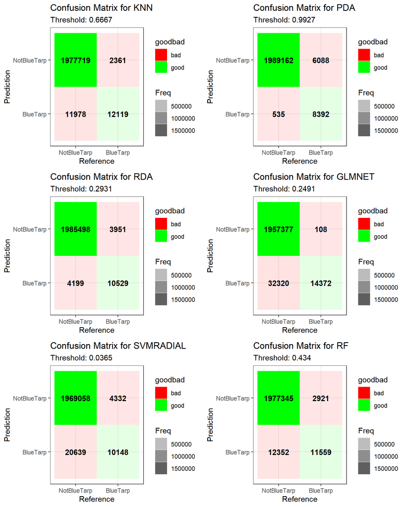

```r
gridExtra::grid.arrange(knn_cfm_plot_ho,lda_cfm_plot_ho ,qda_cfm_plot_ho, lr_cfm_plot_ho,
  svm_cfm_plot_ho, rf_cfm_plot_ho, nrow = 3)
```

# 5 Cost-Matrix

ref: ml-jasonB

In Cost Sensitive learning, we deliberately use different costs as penalty with each type model errors then calculate the total cost associated with the prediction errors. The goal here is to minimze the cost of prediction errors. This is a wide field in itself, the cost can be calculated on the basis of - prediction errors - labeling errors (threshold) - compute complexity… etc.,

I am taking a simple approach of associating cost with model prediction error (false positive) as cost incurred and that should be included as part of the overall budget. So we will be interested to see it a model fares better purely from a budget perspective, and asses if the best threshold based predictions are inline or outside of the budget allocated.

The holdout dataset we are dealing with is highly imbalanced. The *BlueTarp* is a minority and a positive class, and *NOTBlueTarp* is a majority and a negative class.

We assume there is no cost for both *False Negative* and *True Negative* predictions. This is thinking purely from budget perspective, and it is not easy to quantify the cost of not reaching people in case of *False Negative* predictions.

Since we have already computed the best threshold for each model and made predictions based on each model, our goal would be to assess which model performs predictions better from a cost perspective. To calculate the total cost from the confusion matrix, we arrive after predicting for each model when computed if, within the assumed budget, we would consider the project to be successful.

Total Cost = Cost of True Positives * True Positives + Cost of False Positives * False Positives

```r
#' Function to calculate the total cost and assess if it is within budget or not
get_cost_matrix_eval <- function (cfm, method) {
  #budget = 10000000
  #cost_matrix <- matrix(c(250, 500,0,0), nrow=2, ncol=2, byrow=TRUE)
  cost = cfm$table[1,1] * 250 + cfm$table[1,2] * 500
  if (cost < 5000000) {
    print (paste(method, cost, "prediction cost is within budget"))
  } else {
    print (paste(method, cost, "prediction cost is outside the budget"))
  }
}
knn_cost <- get_cost_matrix_eval(knn_cfm_ho, 'knn')
```

```
## [1] "knn 9018750 prediction cost is outside the budget"
```

```r
lda_cost <- get_cost_matrix_eval(lda_cfm_ho, 'lda')
```

```
## [1] "lda 2365500 prediction cost is within budget"
```

```r
qda_cost <- get_cost_matrix_eval(qda_cfm_ho, 'qda')
```

```
## [1] "qda 4731750 prediction cost is within budget"
```

```r
lr_cost <- get_cost_matrix_eval(lr_cfm_ho, 'lr')
```

```
## [1] "lr 19753000 prediction cost is outside the budget"
```

```r
svm_cost <- get_cost_matrix_eval(svm_cfm_ho, 'svm')
```

```
## [1] "svm 12856500 prediction cost is outside the budget"
```

```r
rf_cost <- get_cost_matrix_eval(rf_cfm_ho, 'rf')
```

```
## [1] "rf 9065750 prediction cost is outside the budget"
```

Cleanup

```r
# ref: multi-core
stopImplicitCluster()

#unregister
#unregister()
```

# 6 Results

## 6.1 K-folds out of sampling performance

[figure not shown]

## 6.2 Hold-fold sample performance

[figure not shown]

Performance metrics for the model with best threshold varied besides accuracy, the change in precision and recall values resulted in different PR AUC and ROC curves on the holdout dataset, as can seen in the plot shown in earlier sections.

# 7 Conclusion

Conclusion:

1. A discussion of the best performing algorithm(s) in the cross-validation and holdout data
- which algorithms appear to be reasonable/good choices for use according to cross-validation?
- which algorithms actually ended up performing well in the holdout data?

In cross-validation, the three models, KNN, SVM, and RF models fare better. All three models have high accuracy and high precision, which is one of this project’s goals. Precision minimizes false positives and maximizes the best utilization of resources to help people in need. What is interesting is RDA (a variant of QDA) has high precision minimizes false positives but performs poorly on false negatives compared to the top three (KNN, SVM, and RF). The LDA did not perform well with the precision score compared to other models. it has the lowes precision (shown in the above metric table)

When dealing with an imbalanced dataset, it is important to select a model that minimizes false positives (when the minority class is a positive class) and does well in balancing the false negatives. With the default threshold=0.5, KNN, SVM, and RF models have high precision and recall scores. They are certainly good candidate models.

**Analyzing the confusion matrix, KNN does seem to do better in minimizing and balancing false positives and false negatives.**

2. 2.A discussion or analysis justifying why your findings above are compatible or reconcilable
- Do the answers to both of the above questions agree? (I.e., are they compatible?) If not, do you have any reasons why they might not agree? (I.e., can they be reconciled somehow?)

In part1, we concluded that KNN performed better on the holdout data set than other models (LDA, QDA, and LR). However, that finding does hold good any more than prediction results on the holdout out dataset in part2 of this project., The three reasons why this may be occurring is

In part1, the best threshold was used determined from ROC curves (pROC package can calculate and show the best threshold on the curve itself). This measure is more suitable for a balanced dataset in binary classification. In part 2, we calculated the best threshold PR_curve using F0.5-measure (harmonic mean), which minimizes false positives. The holdout dataset in part 2 is even more highly imbalanced compared to the training dataset. Training data has around 3.2% of BlueTarps, where was the holdout dataset has only .72% blue Tarps. The huge dataset and sampling variation affecting the model’s precision accuracy in cross folds could be another reason why the best performing model in part 1 did not perform well in part 2.

3. The recommendation and rationale regarding which algorithm to use for the detection of blue tarps.

Training dataset: As noted above for the training data in part2, KNN does preform better than other models.

Holdout dataset: Analyzing the confusion matrix and performance metrics for all models, one can make an argument that the GLMNET LR model does better in predicting true positive (BlueTarp), similarly. RF, KNN, and SVM models predict almost equal (KNN) or far greater than true positives. This indicates that the precision score is less than the recall score for these. models. As the goal is to minimize false positives, comparing all models (including LDA ~’ pda’ implementation’). The QDA model (‘rda’ implementation) has more balanced false positive and false negative predictions with reasonably good true positive predictions

4. A discussion of the relevance of the metrics calculated in the tables to this application context

ref: ml-JasonB

**Accuracy**: Accuracy is the most widely used metric, which is the ratio of the number of correct predictions to the model’s total predictions. From the analysis of this project, it is clear now that accuracy is not always the best measure of classification performance. A model can have high accuracy in imbalanced classification by always predicting the majority class correctly even though that happens to be the negative class.

** Threshold**: Threshold is a numeric value between 0 and 1 used for converting the prediction probabilities into class labels. The default threshold value is 0.5, and often we try to find the optimum or best threshold value for a model for a specific dataset. The optimum threshold can be found from the ROC curve or the precision-recall curve.

**PR CURVE PR AUC**: The Precision-Recall curve and AUC are more useful for imbalanced datasets, primarily focus on the minority classes. The precision-recall curve is calculated by creating the class labels from the probability predictions across a range of thresholds between 0 and 1 and then calculating the precision-recall at each threshold value.

**Sensitivity**: It is also referred to as the true positive rate. It measures how well the model is predicting true positives.

```
Sensitivity  = TP / (TP + FN)
```

**Specifitivity**: also referred to as true negative rate, this measures how well the model is predicting negative classes

```
Specificity =  TN / (FP + TN)
```

In an imbalanced dataset like the one used in this classification, sensitivity important than specificity. The minority positive class prediction is what we are interested in, so we care about sensitivity.

**Precision**: Precision measures how well the model predicts true positives of all the positive classes assigned during the classification. A higher precision score minimizes false positives. This measure we are interested in for this case study as we have a highly imbalanced dataset

```
Precision = TP / (TP + FP)
```

**Recall**: Recall is the same as sensitivity when it comes to calculations, but the interpretation here would be that it measures how well the model predicts positive classes. Recall minimizes the false negatives.

```
Recall = TP / ( TP + FN)
```

**False Discovery Rate (FDR): is the measure of all false positives predicted by the mode of all the positives predicted

```
FDR =   FP / (FP+TP)
```

5.Understanding and appreciating uncertainty in the accuracy of point estimates.

As I have shown above through detailed analysis, there is considerable variation in the model performance metrics - sensitivity, the true positive rate across all the out-of-sample folds, for each model, let alone the sampling variation in the entire dataset. So we can not take point estimates as accurate performance measures for a classification problem. We need to analyze thoroughly and understand the potential uncertainty in our dataset.

6. Finding the Optimal Threshold for Imbalanced data sets: In our study, we configured the caret train control object to return all class probabilities, and these uses these probabilities to predict the class label as ‘BlueTarp or ’NotBlueTarp.’ by using a threshold value, and we need to find an optimum threshold value for each model fit for our particular dataset for a classification problem.

The optimum threshold value can be calculated from the ROC curve and the precision-recall curve. The ROC curve tries to find the optimum balance between true positive(sensitivity) and false-positive rates (specificity). So thresholding using ROC curves is more favored for balanced data sets.

The Precision recall curve depends on precision and recall values, so it focuses on the minority positive class in the dataset. In this project, we wanted to get high precision and high recall scores so that our model performs better in minimizing the false positives and false negatives, but often it is hard to achieve. F-measure is the harmonic mean that summarizes the model’s model performance by combining both precision and recall. When we are interested in predicting more true positives, we should be able to sue the F$\beta$ measure and extension of the f- feature. For our analysis, we used F0.5- a measure that puts more weight on precision and less on recall.

In conclusion, even though we did cross-validation, tuned hyper parameters, and labeled classes for each models’ prediction probabilities using the corresponding best threshold value, the model that performed better with the training set did not perform well with the holdout dataset.This could due to the fact that complex models tend to overfit the training data and do not yeild the same level of prediction accuracy with new holdout data & the uncertainty in model performance that is because of sampling variation in highly imbalanced dataset.

I look forward to explore further & learn more about detail different model evaluation techniques…